# INN Hotels Project

## Context

A significant number of hotel bookings are called-off due to cancellations or no-shows. The typical reasons for cancellations include change of plans, scheduling conflicts, etc. This is often made easier by the option to do so free of charge or preferably at a low cost which is beneficial to hotel guests but it is a less desirable and possibly revenue-diminishing factor for hotels to deal with. Such losses are particularly high on last-minute cancellations.

The new technologies involving online booking channels have dramatically changed customers’ booking possibilities and behavior. This adds a further dimension to the challenge of how hotels handle cancellations, which are no longer limited to traditional booking and guest characteristics.

The cancellation of bookings impact a hotel on various fronts:

- Loss of resources (revenue) when the hotel cannot resell the room.
- Additional costs of distribution channels by increasing commissions or paying for publicity to help sell these rooms.
- Lowering prices last minute, so the hotel can resell a room, resulting in reducing the profit margin.
- Human resources to make arrangements for the guests.

## Objective

The increasing number of cancellations calls for a Machine Learning based solution that can help in predicting which booking is likely to be canceled. INN Hotels Group has a chain of hotels in Portugal, they are facing problems with the high number of booking cancellations and have reached out to your firm for data-driven solutions. You as a data scientist have to analyze the data provided to find which factors have a high influence on booking cancellations, build a predictive model that can predict which booking is going to be canceled in advance, and help in formulating profitable policies for cancellations and refunds.

## Data Description

The data contains the different attributes of customers' booking details. The detailed data dictionary is given below.

**Data Dictionary**

- Booking_ID: unique identifier of each booking
- no_of_adults: Number of adults
- no_of_children: Number of Children
- no_of_weekend_nights: Number of weekend nights (Saturday or Sunday) the guest stayed or booked to stay at the hotel
- no_of_week_nights: Number of week nights (Monday to Friday) the guest stayed or booked to stay at the hotel
- type_of_meal_plan: Type of meal plan booked by the customer:
  - Not Selected – No meal plan selected
  - Meal Plan 1 – Breakfast
  - Meal Plan 2 – Half board (breakfast and one other meal)
  - Meal Plan 3 – Full board (breakfast, lunch, and dinner)
- required_car_parking_space: Does the customer require a car parking space? (0 - No, 1- Yes)
- room_type_reserved: Type of room reserved by the customer. The values are ciphered (encoded) by INN Hotels.
- lead_time: Number of days between the date of booking and the arrival date
- arrival_year: Year of arrival date
- arrival_month: Month of arrival date
- arrival_date: Date of the month
- market_segment_type: Market segment designation.
- repeated_guest: Is the customer a repeated guest? (0 - No, 1- Yes)
- no_of_previous_cancellations: Number of previous bookings that were canceled by the customer prior to the current booking
- no_of_previous_bookings_not_canceled: Number of previous bookings not canceled by the customer prior to the current booking
- avg_price_per_room: Average price per day of the reservation; prices of the rooms are dynamic. (in euros)
- no_of_special_requests: Total number of special requests made by the customer (e.g. high floor, view from the room, etc)
- booking_status: Flag indicating if the booking was canceled or not.

## Importing necessary libraries and data

```python
import pandas as pd
import numpy as np
from sklearn import metrics
import matplotlib.pyplot as plt
%matplotlib inline
import seaborn as sns
from sklearn.model_selection import train_test_split
from sklearn.tree import DecisionTreeClassifier
from sklearn import tree
```

```python
# To build model for prediction
import statsmodels.stats.api as sms
from statsmodels.stats.outliers_influence import variance_inflation_factor
import statsmodels.api as sm
from statsmodels.tools.tools import add_constant
from sklearn.linear_model import LogisticRegression


# To get diferent metric scores
from sklearn.metrics import (
    f1_score,
    accuracy_score,
    recall_score,
    precision_score,
    confusion_matrix,
    roc_auc_score,
    plot_confusion_matrix,
    precision_recall_curve,
    roc_curve,
)
```

## Data Overview

- Observations
- Sanity checks

```python
hotel=pd.read_csv("INNHotelsGroup.csv")
```

```python
hotel.head()
```

|  | Booking_ID | no_of_adults | no_of_children | no_of_weekend_nights | no_of_week_nights | type_of_meal_plan | required_car_parking_space | room_type_reserved | lead_time | arrival_year | arrival_month | arrival_date | market_segment_type | repeated_guest | no_of_previous_cancellations | no_of_previous_bookings_not_canceled | avg_price_per_room | no_of_special_requests | booking_status |
| --- | --- | --- | --- | --- | --- | --- | --- | --- | --- | --- | --- | --- | --- | --- | --- | --- | --- | --- | --- |
| 0 | INN00001 | 2 | 0 | 1 | 2 | Meal Plan 1 | 0 | Room_Type 1 | 224 | 2017 | 10 | 2 | Offline | 0 | 0 | 0 | 65.00 | 0 | Not_Canceled |
| 1 | INN00002 | 2 | 0 | 2 | 3 | Not Selected | 0 | Room_Type 1 | 5 | 2018 | 11 | 6 | Online | 0 | 0 | 0 | 106.68 | 1 | Not_Canceled |
| 2 | INN00003 | 1 | 0 | 2 | 1 | Meal Plan 1 | 0 | Room_Type 1 | 1 | 2018 | 2 | 28 | Online | 0 | 0 | 0 | 60.00 | 0 | Canceled |
| 3 | INN00004 | 2 | 0 | 0 | 2 | Meal Plan 1 | 0 | Room_Type 1 | 211 | 2018 | 5 | 20 | Online | 0 | 0 | 0 | 100.00 | 0 | Canceled |
| 4 | INN00005 | 2 | 0 | 1 | 1 | Not Selected | 0 | Room_Type 1 | 48 | 2018 | 4 | 11 | Online | 0 | 0 | 0 | 94.50 | 0 | Canceled |

```python
hotel.shape
```

```
(36275, 19)
```

Hotel data has 36275 rows and 19 columns

```python
hotel.describe()
```

|  | no_of_adults | no_of_children | no_of_weekend_nights | no_of_week_nights | required_car_parking_space | lead_time | arrival_year | arrival_month | arrival_date | repeated_guest | no_of_previous_cancellations | no_of_previous_bookings_not_canceled | avg_price_per_room | no_of_special_requests |
| --- | --- | --- | --- | --- | --- | --- | --- | --- | --- | --- | --- | --- | --- | --- |
| count | 36275.000000 | 36275.000000 | 36275.000000 | 36275.000000 | 36275.000000 | 36275.000000 | 36275.000000 | 36275.000000 | 36275.000000 | 36275.000000 | 36275.000000 | 36275.000000 | 36275.000000 | 36275.000000 |
| mean | 1.844962 | 0.105279 | 0.810724 | 2.204300 | 0.030986 | 85.232557 | 2017.820427 | 7.423653 | 15.596995 | 0.025637 | 0.023349 | 0.153411 | 103.423539 | 0.619655 |
| std | 0.518715 | 0.402648 | 0.870644 | 1.410905 | 0.173281 | 85.930817 | 0.383836 | 3.069894 | 8.740447 | 0.158053 | 0.368331 | 1.754171 | 35.089424 | 0.786236 |
| min | 0.000000 | 0.000000 | 0.000000 | 0.000000 | 0.000000 | 0.000000 | 2017.000000 | 1.000000 | 1.000000 | 0.000000 | 0.000000 | 0.000000 | 0.000000 | 0.000000 |
| 25% | 2.000000 | 0.000000 | 0.000000 | 1.000000 | 0.000000 | 17.000000 | 2018.000000 | 5.000000 | 8.000000 | 0.000000 | 0.000000 | 0.000000 | 80.300000 | 0.000000 |
| 50% | 2.000000 | 0.000000 | 1.000000 | 2.000000 | 0.000000 | 57.000000 | 2018.000000 | 8.000000 | 16.000000 | 0.000000 | 0.000000 | 0.000000 | 99.450000 | 0.000000 |
| 75% | 2.000000 | 0.000000 | 2.000000 | 3.000000 | 0.000000 | 126.000000 | 2018.000000 | 10.000000 | 23.000000 | 0.000000 | 0.000000 | 0.000000 | 120.000000 | 1.000000 |
| max | 4.000000 | 10.000000 | 7.000000 | 17.000000 | 1.000000 | 443.000000 | 2018.000000 | 12.000000 | 31.000000 | 1.000000 | 13.000000 | 58.000000 | 540.000000 | 5.000000 |

```python
hotel.info()
```

```
<class 'pandas.core.frame.DataFrame'>
RangeIndex: 36275 entries, 0 to 36274
Data columns (total 19 columns):
 #   Column                                Non-Null Count  Dtype
---  ------                                --------------  -----
 0   Booking_ID                            36275 non-null  object
 1   no_of_adults                          36275 non-null  int64
 2   no_of_children                        36275 non-null  int64
 3   no_of_weekend_nights                  36275 non-null  int64
 4   no_of_week_nights                     36275 non-null  int64
 5   type_of_meal_plan                     36275 non-null  object
 6   required_car_parking_space            36275 non-null  int64
 7   room_type_reserved                    36275 non-null  object
 8   lead_time                             36275 non-null  int64
 9   arrival_year                          36275 non-null  int64
 10  arrival_month                         36275 non-null  int64
 11  arrival_date                          36275 non-null  int64
 12  market_segment_type                   36275 non-null  object
 13  repeated_guest                        36275 non-null  int64
 14  no_of_previous_cancellations          36275 non-null  int64
 15  no_of_previous_bookings_not_canceled  36275 non-null  int64
 16  avg_price_per_room                    36275 non-null  float64
 17  no_of_special_requests                36275 non-null  int64
 18  booking_status                        36275 non-null  object
dtypes: float64(1), int64(13), object(5)
memory usage: 5.3+ MB
```

```python
hotel.isnull().sum()
```

```
Booking_ID                              0
no_of_adults                            0
no_of_children                          0
no_of_weekend_nights                    0
no_of_week_nights                       0
type_of_meal_plan                       0
required_car_parking_space              0
room_type_reserved                      0
lead_time                               0
arrival_year                            0
arrival_month                           0
arrival_date                            0
market_segment_type                     0
repeated_guest                          0
no_of_previous_cancellations            0
no_of_previous_bookings_not_canceled    0
avg_price_per_room                      0
no_of_special_requests                  0
booking_status                          0
dtype: int64
```

```python
hotel.describe(include="all").T
```

|  | count | unique | top | freq | mean | std | min | 25% | 50% | 75% | max |
| --- | --- | --- | --- | --- | --- | --- | --- | --- | --- | --- | --- |
| Booking_ID | 36275 | 36275 | INN00001 | 1 | NaN | NaN | NaN | NaN | NaN | NaN | NaN |
| no_of_adults | 36275.0 | NaN | NaN | NaN | 1.844962 | 0.518715 | 0.0 | 2.0 | 2.0 | 2.0 | 4.0 |
| no_of_children | 36275.0 | NaN | NaN | NaN | 0.105279 | 0.402648 | 0.0 | 0.0 | 0.0 | 0.0 | 10.0 |
| no_of_weekend_nights | 36275.0 | NaN | NaN | NaN | 0.810724 | 0.870644 | 0.0 | 0.0 | 1.0 | 2.0 | 7.0 |
| no_of_week_nights | 36275.0 | NaN | NaN | NaN | 2.2043 | 1.410905 | 0.0 | 1.0 | 2.0 | 3.0 | 17.0 |
| type_of_meal_plan | 36275 | 4 | Meal Plan 1 | 27835 | NaN | NaN | NaN | NaN | NaN | NaN | NaN |
| required_car_parking_space | 36275.0 | NaN | NaN | NaN | 0.030986 | 0.173281 | 0.0 | 0.0 | 0.0 | 0.0 | 1.0 |
| room_type_reserved | 36275 | 7 | Room_Type 1 | 28130 | NaN | NaN | NaN | NaN | NaN | NaN | NaN |
| lead_time | 36275.0 | NaN | NaN | NaN | 85.232557 | 85.930817 | 0.0 | 17.0 | 57.0 | 126.0 | 443.0 |
| arrival_year | 36275.0 | NaN | NaN | NaN | 2017.820427 | 0.383836 | 2017.0 | 2018.0 | 2018.0 | 2018.0 | 2018.0 |
| arrival_month | 36275.0 | NaN | NaN | NaN | 7.423653 | 3.069894 | 1.0 | 5.0 | 8.0 | 10.0 | 12.0 |
| arrival_date | 36275.0 | NaN | NaN | NaN | 15.596995 | 8.740447 | 1.0 | 8.0 | 16.0 | 23.0 | 31.0 |
| market_segment_type | 36275 | 5 | Online | 23214 | NaN | NaN | NaN | NaN | NaN | NaN | NaN |
| repeated_guest | 36275.0 | NaN | NaN | NaN | 0.025637 | 0.158053 | 0.0 | 0.0 | 0.0 | 0.0 | 1.0 |
| no_of_previous_cancellations | 36275.0 | NaN | NaN | NaN | 0.023349 | 0.368331 | 0.0 | 0.0 | 0.0 | 0.0 | 13.0 |
| no_of_previous_bookings_not_canceled | 36275.0 | NaN | NaN | NaN | 0.153411 | 1.754171 | 0.0 | 0.0 | 0.0 | 0.0 | 58.0 |
| avg_price_per_room | 36275.0 | NaN | NaN | NaN | 103.423539 | 35.089424 | 0.0 | 80.3 | 99.45 | 120.0 | 540.0 |
| no_of_special_requests | 36275.0 | NaN | NaN | NaN | 0.619655 | 0.786236 | 0.0 | 0.0 | 0.0 | 1.0 | 5.0 |
| booking_status | 36275 | 2 | Not_Canceled | 24390 | NaN | NaN | NaN | NaN | NaN | NaN | NaN |

```python
print(hotel.type_of_meal_plan.value_counts())
print(hotel.room_type_reserved.value_counts())
print(hotel.market_segment_type.value_counts())
print(hotel.booking_status.value_counts())
```

```
Meal Plan 1     27835
Not Selected     5130
Meal Plan 2      3305
Meal Plan 3         5
Name: type_of_meal_plan, dtype: int64
Room_Type 1    28130
Room_Type 4     6057
Room_Type 6      966
Room_Type 2      692
Room_Type 5      265
Room_Type 7      158
Room_Type 3        7
Name: room_type_reserved, dtype: int64
Online           23214
Offline          10528
Corporate         2017
Complementary      391
Aviation           125
Name: market_segment_type, dtype: int64
Not_Canceled    24390
Canceled        11885
Name: booking_status, dtype: int64
```

```python
hotel['market_segment_type'].unique()
```

```
array(['Offline', 'Online', 'Corporate', 'Aviation', 'Complementary'],
      dtype=object)
```

## Exploratory Data Analysis (EDA)

- EDA is an important part of any project involving data.
- It is important to investigate and understand the data better before building a model with it.
- A few questions have been mentioned below which will help you approach the analysis in the right manner and generate insights from the data.
- A thorough analysis of the data, in addition to the questions mentioned below, should be done.

**Leading Questions**:

1. What are the busiest months in the hotel?
2. Which market segment do most of the guests come from?
3. Hotel rates are dynamic and change according to demand and customer demographics. What are the differences in room prices in different market segments?
4. What percentage of bookings are canceled?
5. Repeating guests are the guests who stay in the hotel often and are important to brand equity. What percentage of repeating guests cancel?
6. Many guests have special requirements when booking a hotel room. Do these requirements affect booking cancellation?
1. What are the busiest months in the hotel?

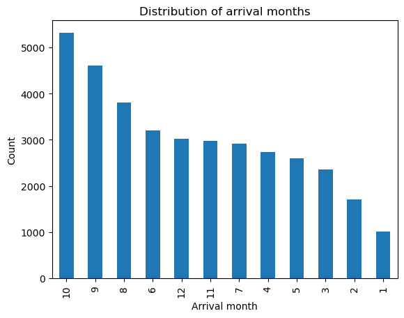

```python
hotel['arrival_month'].value_counts().plot(kind='bar')
plt.xlabel('Arrival month')
plt.ylabel('Count')
plt.title('Distribution of arrival months')
plt.show()
```

```
     October is the busiest month of the year
```

1. Which market segment do most of the guests come from?

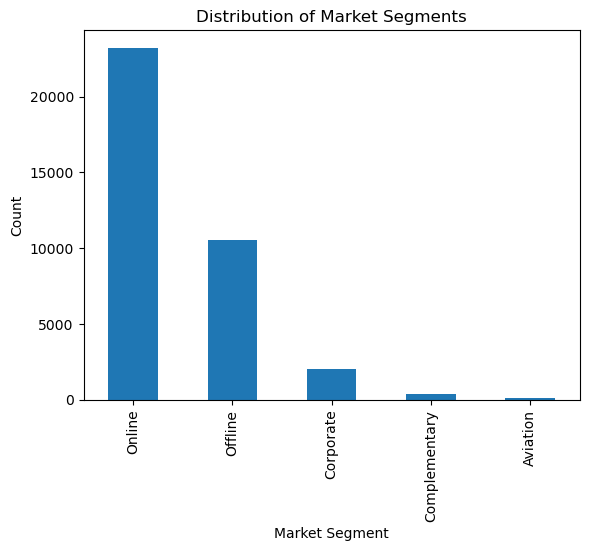

```python
hotel['market_segment_type'].value_counts().plot(kind='bar')
plt.xlabel('Market Segment')
plt.ylabel('Count')
plt.title('Distribution of Market Segments')
plt.show()
```

Most guests come from Online Market Segment

1. Hotel rates are dynamic and change according to demand and customer demographics. What are the differences in room prices in different market segments?

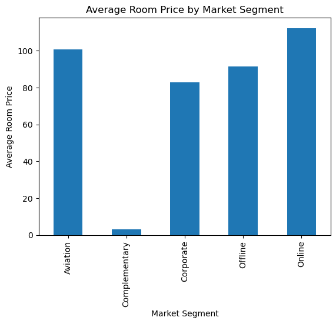

```python
hotel.groupby('market_segment_type')['avg_price_per_room'].mean().plot(kind='bar')
plt.xlabel('Market Segment')
plt.ylabel('Average Room Price')
plt.title('Average Room Price by Market Segment')
plt.show()
```

1. What percentage of bookings are canceled?

```python
canceled_bookings = len(hotel[hotel['booking_status'] == 'Canceled'])
total_bookings = len(hotel)
canceled_percentage = (canceled_bookings / total_bookings) * 100
print("Percentage of bookings canceled: {:.2f}%".format(canceled_percentage))
```

```
Percentage of bookings canceled: 32.76%
```

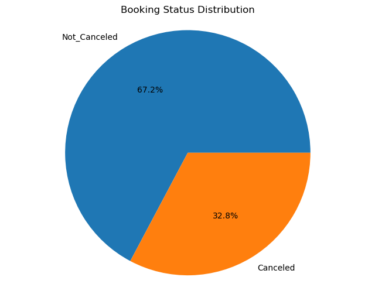

```python
booking_status_counts = hotel['booking_status'].value_counts()
labels = booking_status_counts.index
values = booking_status_counts.values

plt.figure(figsize=(8, 6))
plt.pie(values, labels=labels, autopct='%1.1f%%')
plt.title("Booking Status Distribution")
plt.axis('equal')
plt.show()
```

32.8% of bookings are cancelled

Repeating guests are the guests who stay in the hotel often and are important to brand equity. What percentage of repeating guests cancel?

```python
repeated_guests=hotel[hotel['repeated_guest']==1]
print(repeated_guests)

canceled_repeated_guests = len(repeated_guests[repeated_guests['booking_status'] == 'Canceled'])
total_repeated_guests = len(repeated_guests)
canceled_percentage_repeated_guests = (canceled_repeated_guests / total_repeated_guests) * 100
print("Percentage of repeating guests who cancel: {:.2f}%".format(canceled_percentage_repeated_guests))
```

```
      Booking_ID  no_of_adults  no_of_children  no_of_weekend_nights  \
88      INN00089             2               0                     0
145     INN00146             1               0                     0
155     INN00156             1               0                     0
266     INN00267             1               0                     0
288     INN00289             2               0                     0
...          ...           ...             ...                   ...
35999   INN36000             1               0                     1
36029   INN36030             1               0                     0
36079   INN36080             1               0                     0
36080   INN36081             1               0                     1
36110   INN36111             1               0                     2

       no_of_week_nights type_of_meal_plan  required_car_parking_space  \
88                     1      Not Selected                           0
```

[output cut: 65 more lines]

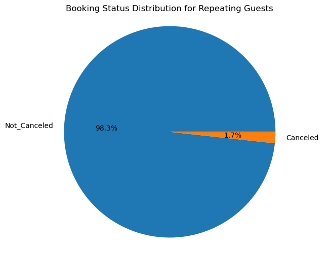

```python
booking_status_counts_repeated_guests = repeated_guests['booking_status'].value_counts()
labels_repeated_guests = booking_status_counts_repeated_guests.index
values_repeated_guests = booking_status_counts_repeated_guests.values

plt.figure(figsize=(8, 6))
plt.pie(values_repeated_guests, labels=labels_repeated_guests, autopct='%1.1f%%')
plt.title("Booking Status Distribution for Repeating Guests")
plt.axis('equal')
plt.show()
```

1.7% of repeated guest cancel the booking which is pretty low compared to oveall cancellations. We could say INN hotels has got some loyal repeated guests.

1. Many guests have special requirements when booking a hotel room. Do these requirements affect booking cancellation?

```python
canceled_with_special_requests = len(hotel[(hotel['no_of_special_requests'] > 0) & (hotel['booking_status'] == 'Canceled')])
total_with_special_requests = len(hotel[hotel['no_of_special_requests'] > 0])

canceled_without_special_requests = len(hotel[(hotel['no_of_special_requests'] == 0) & (hotel['booking_status'] == 'Canceled')])
total_without_special_requests = len(hotel[hotel['no_of_special_requests'] == 0])

cancellation_rate_with_special_requests = (canceled_with_special_requests / total_with_special_requests) * 100
cancellation_rate_without_special_requests = (canceled_without_special_requests / total_without_special_requests) * 100

print("Cancellation rate with special requests: {:.2f}%".format(cancellation_rate_with_special_requests))
print("Cancellation rate without special requests: {:.2f}%".format(cancellation_rate_without_special_requests))
```

```
Cancellation rate with special requests: 20.24%
Cancellation rate without special requests: 43.21%
```

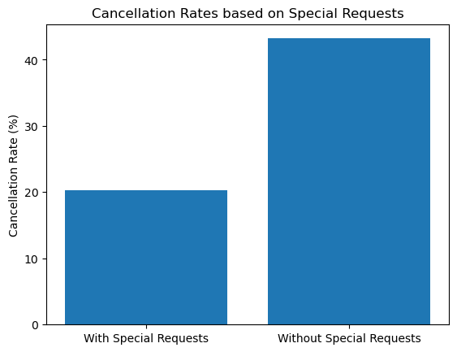

```python
labels = ['With Special Requests', 'Without Special Requests']
values = [cancellation_rate_with_special_requests, cancellation_rate_without_special_requests]

plt.bar(labels, values)
plt.title("Cancellation Rates based on Special Requests")
plt.ylabel("Cancellation Rate (%)")
plt.show()
```

Cancellation rate with special requests: 20.24% Cancellation rate without special requests: 43.21%

Cancellation rate without special requests are almost double compared to cancellation rate with special requests.

```python
hotel.info()
```

```
<class 'pandas.core.frame.DataFrame'>
RangeIndex: 36275 entries, 0 to 36274
Data columns (total 19 columns):
 #   Column                                Non-Null Count  Dtype
---  ------                                --------------  -----
 0   Booking_ID                            36275 non-null  object
 1   no_of_adults                          36275 non-null  int64
 2   no_of_children                        36275 non-null  int64
 3   no_of_weekend_nights                  36275 non-null  int64
 4   no_of_week_nights                     36275 non-null  int64
 5   type_of_meal_plan                     36275 non-null  object
 6   required_car_parking_space            36275 non-null  int64
 7   room_type_reserved                    36275 non-null  object
 8   lead_time                             36275 non-null  int64
 9   arrival_year                          36275 non-null  int64
 10  arrival_month                         36275 non-null  int64
 11  arrival_date                          36275 non-null  int64
 12  market_segment_type                   36275 non-null  object
 13  repeated_guest                        36275 non-null  int64
 14  no_of_previous_cancellations          36275 non-null  int64
 15  no_of_previous_bookings_not_canceled  36275 non-null  int64
 16  avg_price_per_room                    36275 non-null  float64
 17  no_of_special_requests                36275 non-null  int64
 18  booking_status                        36275 non-null  object
dtypes: float64(1), int64(13), object(5)
memory usage: 5.3+ MB
```

```python
hotel.drop('Booking_ID', axis=1, inplace=True)
```

```python
hotel.info()
```

```
<class 'pandas.core.frame.DataFrame'>
RangeIndex: 36275 entries, 0 to 36274
Data columns (total 18 columns):
 #   Column                                Non-Null Count  Dtype
---  ------                                --------------  -----
 0   no_of_adults                          36275 non-null  int64
 1   no_of_children                        36275 non-null  int64
 2   no_of_weekend_nights                  36275 non-null  int64
 3   no_of_week_nights                     36275 non-null  int64
 4   type_of_meal_plan                     36275 non-null  object
 5   required_car_parking_space            36275 non-null  int64
 6   room_type_reserved                    36275 non-null  object
 7   lead_time                             36275 non-null  int64
 8   arrival_year                          36275 non-null  int64
 9   arrival_month                         36275 non-null  int64
 10  arrival_date                          36275 non-null  int64
 11  market_segment_type                   36275 non-null  object
 12  repeated_guest                        36275 non-null  int64
 13  no_of_previous_cancellations          36275 non-null  int64
 14  no_of_previous_bookings_not_canceled  36275 non-null  int64
 15  avg_price_per_room                    36275 non-null  float64
 16  no_of_special_requests                36275 non-null  int64
 17  booking_status                        36275 non-null  object
dtypes: float64(1), int64(13), object(4)
memory usage: 5.0+ MB
```

## Data Preprocessing

- Missing value treatment (if needed)
- Feature engineering (if needed)
- Outlier detection and treatment (if needed)
- Preparing data for modeling
- Any other preprocessing steps (if needed)

```python
hotel.info()
```

```
<class 'pandas.core.frame.DataFrame'>
RangeIndex: 36275 entries, 0 to 36274
Data columns (total 18 columns):
 #   Column                                Non-Null Count  Dtype
---  ------                                --------------  -----
 0   no_of_adults                          36275 non-null  int64
 1   no_of_children                        36275 non-null  int64
 2   no_of_weekend_nights                  36275 non-null  int64
 3   no_of_week_nights                     36275 non-null  int64
 4   type_of_meal_plan                     36275 non-null  object
 5   required_car_parking_space            36275 non-null  int64
 6   room_type_reserved                    36275 non-null  object
 7   lead_time                             36275 non-null  int64
 8   arrival_year                          36275 non-null  int64
 9   arrival_month                         36275 non-null  int64
 10  arrival_date                          36275 non-null  int64
 11  market_segment_type                   36275 non-null  object
 12  repeated_guest                        36275 non-null  int64
 13  no_of_previous_cancellations          36275 non-null  int64
 14  no_of_previous_bookings_not_canceled  36275 non-null  int64
 15  avg_price_per_room                    36275 non-null  float64
 16  no_of_special_requests                36275 non-null  int64
 17  booking_status                        36275 non-null  object
dtypes: float64(1), int64(13), object(4)
memory usage: 5.0+ MB
```

```python
# Convert object Dtypes to Category
columns_o = hotel.select_dtypes(include=["object"]).columns.tolist()
for colname in columns_o:
    hotel[colname] = hotel[colname].astype("category")

# Gather info to get a better understand of the dataset
hotel.info()
print("*" * 50)
print("*" * 50)

# Iterate through the category columns, convert to a list, and print the value counts of each.
columns_c = hotel.select_dtypes(include=["category"]).columns.tolist()
for i in columns_c:
    print(f"Value Count for {i}")
    print(hotel[i].value_counts())
    print(f"To verify total counts {hotel[i].count()}")
    print("*" * 50)
```

```
<class 'pandas.core.frame.DataFrame'>
RangeIndex: 36275 entries, 0 to 36274
Data columns (total 18 columns):
 #   Column                                Non-Null Count  Dtype
---  ------                                --------------  -----
 0   no_of_adults                          36275 non-null  int64
 1   no_of_children                        36275 non-null  int64
 2   no_of_weekend_nights                  36275 non-null  int64
 3   no_of_week_nights                     36275 non-null  int64
 4   type_of_meal_plan                     36275 non-null  category
 5   required_car_parking_space            36275 non-null  int64
 6   room_type_reserved                    36275 non-null  category
 7   lead_time                             36275 non-null  int64
 8   arrival_year                          36275 non-null  int64
 9   arrival_month                         36275 non-null  int64
 10  arrival_date                          36275 non-null  int64
 11  market_segment_type                   36275 non-null  category
 12  repeated_guest                        36275 non-null  int64
 13  no_of_previous_cancellations          36275 non-null  int64
 14  no_of_previous_bookings_not_canceled  36275 non-null  int64
 15  avg_price_per_room                    36275 non-null  float64
 16  no_of_special_requests                36275 non-null  int64
 17  booking_status                        36275 non-null  category
dtypes: category(4), float64(1), int64(13)
memory usage: 4.0 MB
Value Count for type_of_meal_plan
Meal Plan 1     27835
Not Selected     5130
Meal Plan 2      3305
Meal Plan 3         5
Name: type_of_meal_plan, dtype: int64
To verify total counts 36275
Value Count for room_type_reserved
Room_Type 1    28130
Room_Type 4     6057
Room_Type 6      966
Room_Type 2      692
Room_Type 5      265
Room_Type 7      158
Room_Type 3        7
Name: room_type_reserved, dtype: int64
To verify total counts 36275
Value Count for market_segment_type
Online           23214
Offline          10528
Corporate         2017
Complementary      391
Aviation           125
Name: market_segment_type, dtype: int64
To verify total counts 36275
Value Count for booking_status
Not_Canceled    24390
Canceled        11885
Name: booking_status, dtype: int64
To verify total counts 36275
```

```python
# Convert Year, Month, and Day to a Date Integer for processing
hotel["dateInt"] = (
    hotel["arrival_year"].astype(str)
    + "-"
    + hotel["arrival_month"].astype(str).str.zfill(2)
    + "-"
    + hotel["arrival_date"].astype(str).str.zfill(2)
)

# Convert the DateInt Colum to a datetime dtype
hotel = hotel[hotel["dateInt"] != "2018-02-29"]
hotel["Date"] = pd.to_datetime(hotel["dateInt"], format="%Y-%m-%d")
hotel = hotel.drop("dateInt", axis=1)

#Convert Date to day of week
hotel["DayofWeek"] = hotel["Date"].dt.day_name().astype("category")
hotel = hotel.drop("arrival_date", axis=1)
hotel.info()
```

```
<class 'pandas.core.frame.DataFrame'>
Int64Index: 36238 entries, 0 to 36274
Data columns (total 19 columns):
 #   Column                                Non-Null Count  Dtype
---  ------                                --------------  -----
 0   no_of_adults                          36238 non-null  int64
 1   no_of_children                        36238 non-null  int64
 2   no_of_weekend_nights                  36238 non-null  int64
 3   no_of_week_nights                     36238 non-null  int64
 4   type_of_meal_plan                     36238 non-null  category
 5   required_car_parking_space            36238 non-null  int64
 6   room_type_reserved                    36238 non-null  category
 7   lead_time                             36238 non-null  int64
 8   arrival_year                          36238 non-null  int64
 9   arrival_month                         36238 non-null  int64
 10  market_segment_type                   36238 non-null  category
 11  repeated_guest                        36238 non-null  int64
 12  no_of_previous_cancellations          36238 non-null  int64
 13  no_of_previous_bookings_not_canceled  36238 non-null  int64
 14  avg_price_per_room                    36238 non-null  float64
 15  no_of_special_requests                36238 non-null  int64
 16  booking_status                        36238 non-null  category
 17  Date                                  36238 non-null  datetime64[ns]
 18  DayofWeek                             36238 non-null  category
dtypes: category(5), datetime64[ns](1), float64(1), int64(12)
memory usage: 4.3 MB
```

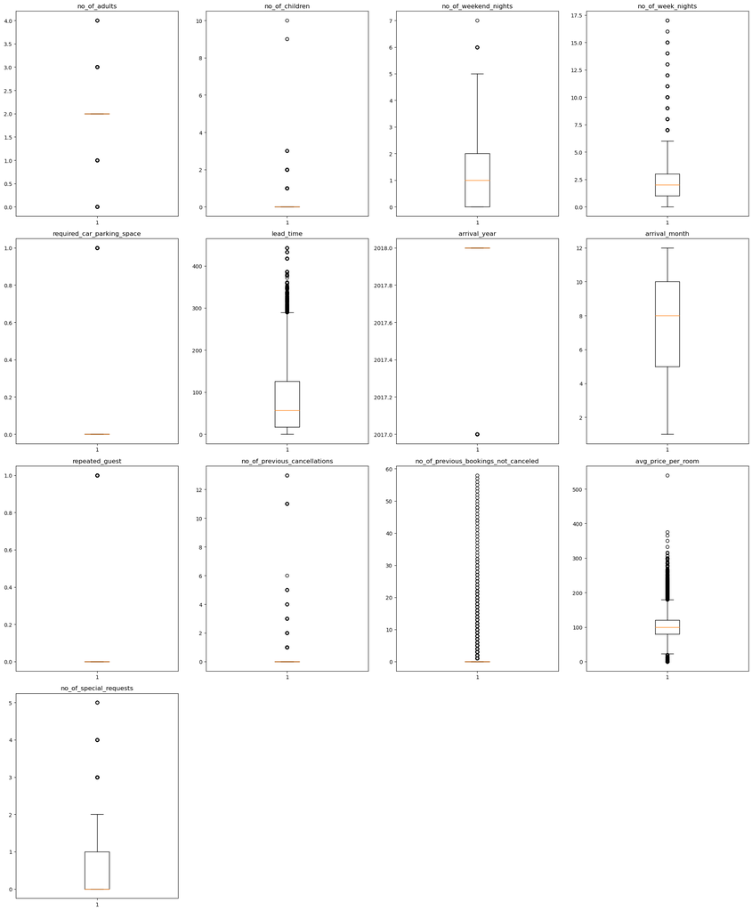

```python
# Reinitialize the new numeric columns
numeric_columns = hotel.select_dtypes(include=np.number).columns.tolist()
# let's plot the boxplots of all columns to check for outliers
plt.figure(figsize=(20, 30))

for i, variable in enumerate(numeric_columns):
    plt.subplot(5, 4, i + 1)
    plt.boxplot(hotel[variable], whis=1.5)
    plt.tight_layout()
    plt.title(variable)

plt.show()
```

Observations:

While checking for outliers, I decided that these outliers for necessary for analysis as the data points could not be easily jusitified removal or scaling.

```python
columns_c = hotel.select_dtypes(include=["int64"]).columns.tolist()
for i in columns_c:
    print(f"Value Count for {i}")
    print(hotel[i].value_counts())
    print(f"To verify total counts {hotel[i].count()}")
    print("*" * 50)
```

```
Value Count for no_of_adults
2    26091
1     7676
3     2316
0      139
4       16
Name: no_of_adults, dtype: int64
To verify total counts 36238
Value Count for no_of_children
0     33544
1      1616
2      1056
3        19
9         2
10        1
```

[output cut: 161 more lines]

```python
hotel.info()
```

```
<class 'pandas.core.frame.DataFrame'>
Int64Index: 36238 entries, 0 to 36274
Data columns (total 19 columns):
 #   Column                                Non-Null Count  Dtype
---  ------                                --------------  -----
 0   no_of_adults                          36238 non-null  int64
 1   no_of_children                        36238 non-null  int64
 2   no_of_weekend_nights                  36238 non-null  int64
 3   no_of_week_nights                     36238 non-null  int64
 4   type_of_meal_plan                     36238 non-null  category
 5   required_car_parking_space            36238 non-null  int64
 6   room_type_reserved                    36238 non-null  category
 7   lead_time                             36238 non-null  int64
 8   arrival_year                          36238 non-null  int64
 9   arrival_month                         36238 non-null  int64
 10  market_segment_type                   36238 non-null  category
 11  repeated_guest                        36238 non-null  int64
 12  no_of_previous_cancellations          36238 non-null  int64
 13  no_of_previous_bookings_not_canceled  36238 non-null  int64
 14  avg_price_per_room                    36238 non-null  float64
 15  no_of_special_requests                36238 non-null  int64
 16  booking_status                        36238 non-null  category
 17  Date                                  36238 non-null  datetime64[ns]
 18  DayofWeek                             36238 non-null  category
dtypes: category(5), datetime64[ns](1), float64(1), int64(12)
memory usage: 4.3 MB
```

```python
# can add custom labels
hotel["lead_time_bin"] = pd.cut(
    hotel["lead_time"],
    [-np.inf, 30, 90, 180, 365, np.inf],
    labels=[
        "30_days",
        "30_to_90_days",
        "90_days_to_half_year",
        "half_year_to_year",
        "more_than_year",
    ],
)
hotel.drop(["lead_time"], axis=1, inplace=True)
hotel["lead_time_bin"].value_counts(dropna=False)
```

```
30_days                 12392
30_to_90_days           10805
90_days_to_half_year     7764
half_year_to_year        5034
more_than_year            243
Name: lead_time_bin, dtype: int64
```

```python
# can add custom labels
hotel["no_of_children_bin"] = pd.cut(
    hotel["no_of_children"],
    [-np.inf, 0, 1, 2, 3, np.inf],
    labels=["0", "1", "2", "3", "4 or more"],
)
hotel.drop(["no_of_children"], axis=1, inplace=True)
hotel["no_of_children_bin"].value_counts(dropna=False)
```

```
0            33544
1             1616
2             1056
3               19
4 or more        3
Name: no_of_children_bin, dtype: int64
```

```python
# can add custom labels
hotel["no_of_previous_bookings_not_canceled_bin"] = pd.cut(
    hotel["no_of_previous_bookings_not_canceled"],
    [-np.inf, 0, 1, 2, 3, 4, 5, 6, 7, 8, 9, 10, np.inf],
    labels=["0", "1", "2", "3", "4", "5", "6", "7", "8", "9", "10", "11 or more"],
)
hotel.drop(["no_of_previous_bookings_not_canceled"], axis=1, inplace=True)
hotel["no_of_previous_bookings_not_canceled_bin"].value_counts(dropna=False)
```

```
0             35429
1               227
11 or more      145
2               112
3                80
4                65
5                60
6                36
7                24
8                23
9                19
10               18
Name: no_of_previous_bookings_not_canceled_bin, dtype: int64
```

```python
# can add custom labels
hotel["no_of_previous_cancellations_bin"] = pd.cut(
    hotel["no_of_previous_cancellations"],
    [-np.inf, 0, 1, 2, 3, 4, 5, np.inf],
    labels=["0", "1", "2", "3", "4", "5", "6 or more"],
)
hotel.drop(["no_of_previous_cancellations"], axis=1, inplace=True)
hotel["no_of_previous_cancellations_bin"].value_counts(dropna=False)
```

```
0            35901
1              197
2               46
3               43
6 or more       30
5               11
4               10
Name: no_of_previous_cancellations_bin, dtype: int64
```

```python
hotel.info()
```

```
<class 'pandas.core.frame.DataFrame'>
Int64Index: 36238 entries, 0 to 36274
Data columns (total 19 columns):
 #   Column                                    Non-Null Count  Dtype
---  ------                                    --------------  -----
 0   no_of_adults                              36238 non-null  int64
 1   no_of_weekend_nights                      36238 non-null  int64
 2   no_of_week_nights                         36238 non-null  int64
 3   type_of_meal_plan                         36238 non-null  category
 4   required_car_parking_space                36238 non-null  int64
 5   room_type_reserved                        36238 non-null  category
 6   arrival_year                              36238 non-null  int64
 7   arrival_month                             36238 non-null  int64
 8   market_segment_type                       36238 non-null  category
 9   repeated_guest                            36238 non-null  int64
 10  avg_price_per_room                        36238 non-null  float64
 11  no_of_special_requests                    36238 non-null  int64
 12  booking_status                            36238 non-null  category
 13  Date                                      36238 non-null  datetime64[ns]
 14  DayofWeek                                 36238 non-null  category
 15  lead_time_bin                             36238 non-null  category
 16  no_of_children_bin                        36238 non-null  category
 17  no_of_previous_bookings_not_canceled_bin  36238 non-null  category
 18  no_of_previous_cancellations_bin          36238 non-null  category
dtypes: category(9), datetime64[ns](1), float64(1), int64(8)
memory usage: 3.4 MB
```

```python
hotel_dt=hotel.copy()
```

```python
# import preprocessing library to encode booking status
from sklearn.preprocessing import LabelEncoder

# transform the booking status to binary
le = LabelEncoder()
booking_status_encoded = le.fit_transform(hotel["booking_status"])

hotel["booking_status_encoded"] = booking_status_encoded
```

## EDA

- It is a good idea to explore the data once again after manipulating it.

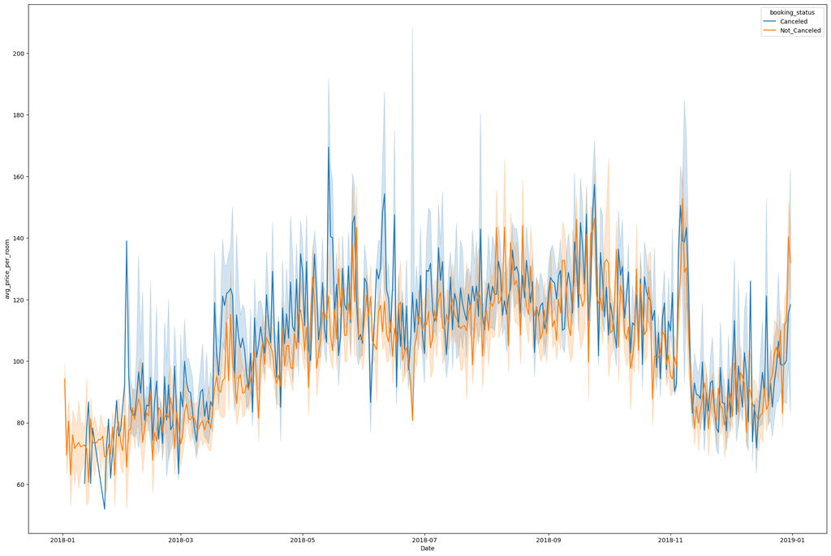

```python
plt.figure(figsize=(24, 16))
sns.lineplot(
    data=hotel[hotel["Date"] > "01-01-2018"],
    x="Date",
    y="avg_price_per_room",
    hue="booking_status",
)
plt.show()
```

```python
hotel.booking_status.value_counts()
```

```
Not_Canceled    24360
Canceled        11878
Name: booking_status, dtype: int64
```

```python
hotel['target_binary'] = np.where(hotel['booking_status']=='Canceled',1,0)
```

## Building a Decision Tree model

```python
# specifying the independent  and dependent variables
X = hotel.drop(["booking_status",'target_binary'], axis=1)
Y = hotel["target_binary"]

# adding a constant to the independent variables
X = sm.add_constant(X)

# creating dummy variables
X = pd.get_dummies(X, drop_first=True)

# splitting data in train and test sets
X_train, X_test, y_train, y_test = train_test_split(
    X, Y, test_size=0.30, random_state=1
)
```

```python
X_train, X_test, y_train, y_test = train_test_split(X, Y, test_size=.30, random_state=1)
```

## Model Building - Logistic Regression

```python
X_train_log = X_train.copy(deep=True)
```

```python
all_columns = list(X_train_log.columns)
```

```python
all_columns.remove('Date')
all_columns.remove('booking_status_encoded')
```

```python
all_columns
```

```
['const',
 'no_of_adults',
 'no_of_weekend_nights',
 'no_of_week_nights',
 'required_car_parking_space',
 'arrival_year',
 'arrival_month',
 'repeated_guest',
 'avg_price_per_room',
 'no_of_special_requests',
 'type_of_meal_plan_Meal Plan 2',
 'type_of_meal_plan_Meal Plan 3',
 'type_of_meal_plan_Not Selected',
 'room_type_reserved_Room_Type 2',
 'room_type_reserved_Room_Type 3',
 'room_type_reserved_Room_Type 4',
 'room_type_reserved_Room_Type 5',
 'room_type_reserved_Room_Type 6',
 'room_type_reserved_Room_Type 7',
 'market_segment_type_Complementary',
 'market_segment_type_Corporate',
 'market_segment_type_Offline',
 'market_segment_type_Online',
 'DayofWeek_Monday',
 'DayofWeek_Saturday',
 'DayofWeek_Sunday',
 'DayofWeek_Thursday',
 'DayofWeek_Tuesday',
 'DayofWeek_Wednesday',
 'lead_time_bin_30_to_90_days',
 'lead_time_bin_90_days_to_half_year',
 'lead_time_bin_half_year_to_year',
 'lead_time_bin_more_than_year',
 'no_of_children_bin_1',
 'no_of_children_bin_2',
 'no_of_children_bin_3',
 'no_of_children_bin_4 or more',
 'no_of_previous_bookings_not_canceled_bin_1',
 'no_of_previous_bookings_not_canceled_bin_2',
 'no_of_previous_bookings_not_canceled_bin_3',
 'no_of_previous_bookings_not_canceled_bin_4',
 'no_of_previous_bookings_not_canceled_bin_5',
 'no_of_previous_bookings_not_canceled_bin_6',
 'no_of_previous_bookings_not_canceled_bin_7',
 'no_of_previous_bookings_not_canceled_bin_8',
 'no_of_previous_bookings_not_canceled_bin_9',
 'no_of_previous_bookings_not_canceled_bin_10',
 'no_of_previous_bookings_not_canceled_bin_11 or more',
 'no_of_previous_cancellations_bin_1',
 'no_of_previous_cancellations_bin_2',
 'no_of_previous_cancellations_bin_3',
 'no_of_previous_cancellations_bin_4',
 'no_of_previous_cancellations_bin_5',
 'no_of_previous_cancellations_bin_6 or more']
```

```python
X_train_log = X_train_log[all_columns]
```

```python
X_train_log.dtypes
```

```
const                                                  float64
no_of_adults                                             int64
no_of_weekend_nights                                     int64
no_of_week_nights                                        int64
required_car_parking_space                               int64
arrival_year                                             int64
arrival_month                                            int64
repeated_guest                                           int64
avg_price_per_room                                     float64
no_of_special_requests                                   int64
type_of_meal_plan_Meal Plan 2                            uint8
type_of_meal_plan_Meal Plan 3                            uint8
type_of_meal_plan_Not Selected                           uint8
room_type_reserved_Room_Type 2                           uint8
room_type_reserved_Room_Type 3                           uint8
room_type_reserved_Room_Type 4                           uint8
room_type_reserved_Room_Type 5                           uint8
room_type_reserved_Room_Type 6                           uint8
room_type_reserved_Room_Type 7                           uint8
market_segment_type_Complementary                        uint8
market_segment_type_Corporate                            uint8
market_segment_type_Offline                              uint8
market_segment_type_Online                               uint8
DayofWeek_Monday                                         uint8
DayofWeek_Saturday                                       uint8
DayofWeek_Sunday                                         uint8
DayofWeek_Thursday                                       uint8
DayofWeek_Tuesday                                        uint8
DayofWeek_Wednesday                                      uint8
lead_time_bin_30_to_90_days                              uint8
lead_time_bin_90_days_to_half_year                       uint8
lead_time_bin_half_year_to_year                          uint8
lead_time_bin_more_than_year                             uint8
no_of_children_bin_1                                     uint8
no_of_children_bin_2                                     uint8
no_of_children_bin_3                                     uint8
no_of_children_bin_4 or more                             uint8
no_of_previous_bookings_not_canceled_bin_1               uint8
no_of_previous_bookings_not_canceled_bin_2               uint8
no_of_previous_bookings_not_canceled_bin_3               uint8
no_of_previous_bookings_not_canceled_bin_4               uint8
no_of_previous_bookings_not_canceled_bin_5               uint8
no_of_previous_bookings_not_canceled_bin_6               uint8
no_of_previous_bookings_not_canceled_bin_7               uint8
no_of_previous_bookings_not_canceled_bin_8               uint8
no_of_previous_bookings_not_canceled_bin_9               uint8
no_of_previous_bookings_not_canceled_bin_10              uint8
no_of_previous_bookings_not_canceled_bin_11 or more      uint8
no_of_previous_cancellations_bin_1                       uint8
no_of_previous_cancellations_bin_2                       uint8
no_of_previous_cancellations_bin_3                       uint8
no_of_previous_cancellations_bin_4                       uint8
no_of_previous_cancellations_bin_5                       uint8
no_of_previous_cancellations_bin_6 or more               uint8
dtype: object
```

```python
print("Shape of Training set : ", X_train_log.shape)
print("Shape of test set : ", X_test.shape)
print("Percentage of classes in training set:")
print(y_train.value_counts(normalize=True))
print("Percentage of classes in test set:")
print(y_test.value_counts(normalize=True))
```

```
Shape of Training set :  (25366, 54)
Shape of test set :  (10872, 56)
Percentage of classes in training set:
0    0.67074
1    0.32926
Name: target_binary, dtype: float64
Percentage of classes in test set:
0    0.675681
1    0.324319
Name: target_binary, dtype: float64
```

```python
X_train_log = X_train_log.astype(float)
```

```python
X_train_log
```

|  | const | no_of_adults | no_of_weekend_nights | no_of_week_nights | required_car_parking_space | arrival_year | arrival_month | repeated_guest | avg_price_per_room | no_of_special_requests | ... | no_of_previous_bookings_not_canceled_bin_8 | no_of_previous_bookings_not_canceled_bin_9 | no_of_previous_bookings_not_canceled_bin_10 | no_of_previous_bookings_not_canceled_bin_11 or more | no_of_previous_cancellations_bin_1 | no_of_previous_cancellations_bin_2 | no_of_previous_cancellations_bin_3 | no_of_previous_cancellations_bin_4 | no_of_previous_cancellations_bin_5 | no_of_previous_cancellations_bin_6 or more |
| --- | --- | --- | --- | --- | --- | --- | --- | --- | --- | --- | --- | --- | --- | --- | --- | --- | --- | --- | --- | --- | --- |
| 4124 | 1.0 | 2.0 | 0.0 | 1.0 | 0.0 | 2017.0 | 10.0 | 0.0 | 67.00 | 0.0 | ... | 0.0 | 0.0 | 0.0 | 0.0 | 0.0 | 0.0 | 0.0 | 0.0 | 0.0 | 0.0 |
| 31349 | 1.0 | 3.0 | 0.0 | 4.0 | 0.0 | 2018.0 | 8.0 | 0.0 | 152.10 | 0.0 | ... | 0.0 | 0.0 | 0.0 | 0.0 | 0.0 | 0.0 | 0.0 | 0.0 | 0.0 | 0.0 |
| 10601 | 1.0 | 2.0 | 0.0 | 1.0 | 0.0 | 2018.0 | 2.0 | 0.0 | 90.00 | 0.0 | ... | 0.0 | 0.0 | 0.0 | 0.0 | 0.0 | 0.0 | 0.0 | 0.0 | 0.0 | 0.0 |
| 26095 | 1.0 | 2.0 | 0.0 | 4.0 | 0.0 | 2018.0 | 3.0 | 0.0 | 63.75 | 0.0 | ... | 0.0 | 0.0 | 0.0 | 0.0 | 0.0 | 0.0 | 0.0 | 0.0 | 0.0 | 0.0 |
| 9017 | 1.0 | 2.0 | 1.0 | 2.0 | 0.0 | 2018.0 | 5.0 | 0.0 | 125.33 | 1.0 | ... | 0.0 | 0.0 | 0.0 | 0.0 | 0.0 | 0.0 | 0.0 | 0.0 | 0.0 | 0.0 |
| ... | ... | ... | ... | ... | ... | ... | ... | ... | ... | ... | ... | ... | ... | ... | ... | ... | ... | ... | ... | ... | ... |
| 7818 | 1.0 | 2.0 | 0.0 | 1.0 | 0.0 | 2018.0 | 12.0 | 0.0 | 79.20 | 2.0 | ... | 0.0 | 0.0 | 0.0 | 0.0 | 0.0 | 0.0 | 0.0 | 0.0 | 0.0 | 0.0 |
| 32546 | 1.0 | 2.0 | 1.0 | 2.0 | 0.0 | 2018.0 | 12.0 | 0.0 | 105.00 | 1.0 | ... | 0.0 | 0.0 | 0.0 | 0.0 | 0.0 | 0.0 | 0.0 | 0.0 | 0.0 | 0.0 |
| 5194 | 1.0 | 2.0 | 0.0 | 2.0 | 0.0 | 2018.0 | 8.0 | 0.0 | 135.90 | 2.0 | ... | 0.0 | 0.0 | 0.0 | 0.0 | 0.0 | 0.0 | 0.0 | 0.0 | 0.0 | 0.0 |
| 12187 | 1.0 | 2.0 | 0.0 | 2.0 | 0.0 | 2017.0 | 8.0 | 0.0 | 109.00 | 0.0 | ... | 0.0 | 0.0 | 0.0 | 0.0 | 0.0 | 0.0 | 0.0 | 0.0 | 0.0 | 0.0 |
| 33038 | 1.0 | 2.0 | 0.0 | 3.0 | 0.0 | 2017.0 | 12.0 | 0.0 | 70.00 | 0.0 | ... | 0.0 | 0.0 | 0.0 | 0.0 | 0.0 | 0.0 | 0.0 | 0.0 | 0.0 | 0.0 |

25366 rows × 54 columns

```python
X_train_log.dtypes
```

```
const                                                  float64
no_of_adults                                           float64
no_of_weekend_nights                                   float64
no_of_week_nights                                      float64
required_car_parking_space                             float64
arrival_year                                           float64
arrival_month                                          float64
repeated_guest                                         float64
avg_price_per_room                                     float64
no_of_special_requests                                 float64
type_of_meal_plan_Meal Plan 2                          float64
type_of_meal_plan_Meal Plan 3                          float64
type_of_meal_plan_Not Selected                         float64
room_type_reserved_Room_Type 2                         float64
room_type_reserved_Room_Type 3                         float64
room_type_reserved_Room_Type 4                         float64
room_type_reserved_Room_Type 5                         float64
room_type_reserved_Room_Type 6                         float64
room_type_reserved_Room_Type 7                         float64
market_segment_type_Complementary                      float64
market_segment_type_Corporate                          float64
market_segment_type_Offline                            float64
market_segment_type_Online                             float64
DayofWeek_Monday                                       float64
DayofWeek_Saturday                                     float64
DayofWeek_Sunday                                       float64
DayofWeek_Thursday                                     float64
DayofWeek_Tuesday                                      float64
DayofWeek_Wednesday                                    float64
lead_time_bin_30_to_90_days                            float64
lead_time_bin_90_days_to_half_year                     float64
lead_time_bin_half_year_to_year                        float64
lead_time_bin_more_than_year                           float64
no_of_children_bin_1                                   float64
no_of_children_bin_2                                   float64
no_of_children_bin_3                                   float64
no_of_children_bin_4 or more                           float64
no_of_previous_bookings_not_canceled_bin_1             float64
no_of_previous_bookings_not_canceled_bin_2             float64
no_of_previous_bookings_not_canceled_bin_3             float64
no_of_previous_bookings_not_canceled_bin_4             float64
no_of_previous_bookings_not_canceled_bin_5             float64
no_of_previous_bookings_not_canceled_bin_6             float64
no_of_previous_bookings_not_canceled_bin_7             float64
no_of_previous_bookings_not_canceled_bin_8             float64
no_of_previous_bookings_not_canceled_bin_9             float64
no_of_previous_bookings_not_canceled_bin_10            float64
no_of_previous_bookings_not_canceled_bin_11 or more    float64
no_of_previous_cancellations_bin_1                     float64
no_of_previous_cancellations_bin_2                     float64
no_of_previous_cancellations_bin_3                     float64
no_of_previous_cancellations_bin_4                     float64
no_of_previous_cancellations_bin_5                     float64
no_of_previous_cancellations_bin_6 or more             float64
dtype: object
```

```python
X_train_log.iloc[:,10:20]
```

|  | type_of_meal_plan_Meal Plan 2 | type_of_meal_plan_Meal Plan 3 | type_of_meal_plan_Not Selected | room_type_reserved_Room_Type 2 | room_type_reserved_Room_Type 3 | room_type_reserved_Room_Type 4 | room_type_reserved_Room_Type 5 | room_type_reserved_Room_Type 6 | room_type_reserved_Room_Type 7 | market_segment_type_Complementary |
| --- | --- | --- | --- | --- | --- | --- | --- | --- | --- | --- |
| 4124 | 0.0 | 0.0 | 0.0 | 0.0 | 0.0 | 0.0 | 0.0 | 0.0 | 0.0 | 0.0 |
| 31349 | 0.0 | 0.0 | 0.0 | 0.0 | 0.0 | 1.0 | 0.0 | 0.0 | 0.0 | 0.0 |
| 10601 | 0.0 | 0.0 | 1.0 | 0.0 | 0.0 | 0.0 | 0.0 | 0.0 | 0.0 | 0.0 |
| 26095 | 0.0 | 0.0 | 1.0 | 0.0 | 0.0 | 0.0 | 0.0 | 0.0 | 0.0 | 0.0 |
| 9017 | 0.0 | 0.0 | 0.0 | 0.0 | 0.0 | 0.0 | 0.0 | 0.0 | 0.0 | 0.0 |
| ... | ... | ... | ... | ... | ... | ... | ... | ... | ... | ... |
| 7818 | 0.0 | 0.0 | 1.0 | 0.0 | 0.0 | 0.0 | 0.0 | 0.0 | 0.0 | 0.0 |
| 32546 | 0.0 | 0.0 | 0.0 | 0.0 | 0.0 | 1.0 | 0.0 | 0.0 | 0.0 | 0.0 |
| 5194 | 0.0 | 0.0 | 0.0 | 0.0 | 0.0 | 0.0 | 0.0 | 0.0 | 0.0 | 0.0 |
| 12187 | 1.0 | 0.0 | 0.0 | 0.0 | 0.0 | 0.0 | 0.0 | 0.0 | 0.0 | 0.0 |
| 33038 | 0.0 | 0.0 | 0.0 | 0.0 | 0.0 | 0.0 | 0.0 | 0.0 | 0.0 | 0.0 |

25366 rows × 10 columns

```python
y_train
```

```
4124     0
31349    1
10601    0
26095    1
9017     0
        ..
7818     0
32546    1
5194     0
12187    0
33038    0
Name: target_binary, Length: 25366, dtype: int64
```

```python
# Assuming y_train is a Pandas Series or DataFrame column
y_train_log = pd.get_dummies(y_train)

# Print the encoded labels
print(y_train_log)
```

```
       0  1
4124   1  0
31349  0  1
10601  1  0
26095  0  1
9017   1  0
...   .. ..
7818   1  0
32546  0  1
5194   1  0
12187  1  0
33038  1  0

[25366 rows x 2 columns]
```

```python
X_train_log.columns.tolist()
```

```
['const',
 'no_of_adults',
 'no_of_weekend_nights',
 'no_of_week_nights',
 'required_car_parking_space',
 'arrival_year',
 'arrival_month',
 'repeated_guest',
 'avg_price_per_room',
 'no_of_special_requests',
 'type_of_meal_plan_Meal Plan 2',
 'type_of_meal_plan_Meal Plan 3',
 'type_of_meal_plan_Not Selected',
 'room_type_reserved_Room_Type 2',
 'room_type_reserved_Room_Type 3',
 'room_type_reserved_Room_Type 4',
 'room_type_reserved_Room_Type 5',
 'room_type_reserved_Room_Type 6',
 'room_type_reserved_Room_Type 7',
 'market_segment_type_Complementary',
 'market_segment_type_Corporate',
 'market_segment_type_Offline',
 'market_segment_type_Online',
 'DayofWeek_Monday',
 'DayofWeek_Saturday',
 'DayofWeek_Sunday',
 'DayofWeek_Thursday',
 'DayofWeek_Tuesday',
 'DayofWeek_Wednesday',
 'lead_time_bin_30_to_90_days',
 'lead_time_bin_90_days_to_half_year',
 'lead_time_bin_half_year_to_year',
 'lead_time_bin_more_than_year',
 'no_of_children_bin_1',
 'no_of_children_bin_2',
 'no_of_children_bin_3',
 'no_of_children_bin_4 or more',
 'no_of_previous_bookings_not_canceled_bin_1',
 'no_of_previous_bookings_not_canceled_bin_2',
 'no_of_previous_bookings_not_canceled_bin_3',
 'no_of_previous_bookings_not_canceled_bin_4',
 'no_of_previous_bookings_not_canceled_bin_5',
 'no_of_previous_bookings_not_canceled_bin_6',
 'no_of_previous_bookings_not_canceled_bin_7',
 'no_of_previous_bookings_not_canceled_bin_8',
 'no_of_previous_bookings_not_canceled_bin_9',
 'no_of_previous_bookings_not_canceled_bin_10',
 'no_of_previous_bookings_not_canceled_bin_11 or more',
 'no_of_previous_cancellations_bin_1',
 'no_of_previous_cancellations_bin_2',
 'no_of_previous_cancellations_bin_3',
 'no_of_previous_cancellations_bin_4',
 'no_of_previous_cancellations_bin_5',
 'no_of_previous_cancellations_bin_6 or more']
```

```python
# fitting logistic regression model
logit = sm.Logit(y_train, X_train_log)
lg = logit.fit(disp=False)

print(lg.summary())
```

```
                           Logit Regression Results
==============================================================================
Dep. Variable:          target_binary   No. Observations:                25366
Model:                          Logit   Df Residuals:                    25312
Method:                           MLE   Df Model:                           53
Date:                Thu, 13 Jul 2023   Pseudo R-squ.:                  0.3278
Time:                        16:30:49   Log-Likelihood:                -10804.
converged:                      False   LL-Null:                       -16073.
Covariance Type:            nonrobust   LLR p-value:                     0.000
=======================================================================================================================
                                                          coef    std err          z      P>|z|      [0.025      0.975]
-----------------------------------------------------------------------------------------------------------------------
const                                               -1106.8270    121.995     -9.073      0.000   -1345.933    -867.721
no_of_adults                                            0.0996      0.038      2.608      0.009       0.025       0.174
no_of_weekend_nights                                    0.1648      0.027      6.038      0.000       0.111       0.218
no_of_week_nights                                       0.0099      0.014      0.690      0.490      -0.018       0.038
required_car_parking_space                             -1.6165      0.137    -11.836      0.000      -1.884      -1.349
arrival_year                                            0.5473      0.060      9.054      0.000       0.429       0.666
arrival_month                                          -0.0287      0.006     -4.501      0.000      -0.041      -0.016
repeated_guest                                        -22.1659   6201.064     -0.004      0.997   -1.22e+04    1.21e+04
avg_price_per_room                                      0.0181      0.001     24.139      0.000       0.017       0.020
no_of_special_requests                                 -1.5116      0.031    -49.488      0.000      -1.571      -1.452
type_of_meal_plan_Meal Plan 2                           0.3247      0.066      4.947      0.000       0.196       0.453
type_of_meal_plan_Meal Plan 3                          15.3223   1693.718      0.009      0.993   -3304.305    3334.949
type_of_meal_plan_Not Selected                          0.2218      0.054      4.124      0.000       0.116       0.327
room_type_reserved_Room_Type 2                         -0.6792      0.138     -4.912      0.000      -0.950      -0.408
room_type_reserved_Room_Type 3                         -0.2020      1.201     -0.168      0.866      -2.555       2.151
room_type_reserved_Room_Type 4                         -0.2754      0.054     -5.079      0.000      -0.382      -0.169
room_type_reserved_Room_Type 5                         -0.6472      0.208     -3.110      0.002      -1.055      -0.239
room_type_reserved_Room_Type 6                         -1.0578      0.192     -5.523      0.000      -1.433      -0.682
room_type_reserved_Room_Type 7                         -1.4428      0.321     -4.497      0.000      -2.072      -0.814
market_segment_type_Complementary                     -25.8772   2006.946     -0.013      0.990   -3959.419    3907.665
market_segment_type_Corporate                          -1.1560      0.257     -4.503      0.000      -1.659      -0.653
market_segment_type_Offline                            -2.0573      0.245     -8.413      0.000      -2.537      -1.578
market_segment_type_Online                             -0.3570      0.241     -1.479      0.139      -0.830       0.116
DayofWeek_Monday                                       -0.1426      0.074     -1.927      0.054      -0.288       0.002
DayofWeek_Saturday                                     -0.1153      0.066     -1.760      0.078      -0.244       0.013
DayofWeek_Sunday                                       -0.0374      0.066     -0.565      0.572      -0.167       0.092
DayofWeek_Thursday                                      0.1139      0.068      1.672      0.095      -0.020       0.247
DayofWeek_Tuesday                                      -0.0814      0.085     -0.955      0.340      -0.249       0.086
```

[output cut: 12 more lines]

```
no_of_previous_bookings_not_canceled_bin_4              0.7504      1.428      0.525      0.599      -2.049       3.550
no_of_previous_bookings_not_canceled_bin_5            -13.1822   1834.817     -0.007      0.994   -3609.358    3582.993
no_of_previous_bookings_not_canceled_bin_6              2.4639      1.462      1.685      0.092      -0.401       5.329
no_of_previous_bookings_not_canceled_bin_7            -11.7060   1291.517     -0.009      0.993   -2543.034    2519.622
no_of_previous_bookings_not_canceled_bin_8            -11.2299   1651.249     -0.007      0.995   -3247.619    3225.159
no_of_previous_bookings_not_canceled_bin_9            -14.5741   3946.570     -0.004      0.997   -7749.709    7720.561
no_of_previous_bookings_not_canceled_bin_10           -19.2439   5.42e+04     -0.000      1.000   -1.06e+05    1.06e+05
no_of_previous_bookings_not_canceled_bin_11 or more     1.5237      1.691      0.901      0.368      -1.791       4.838
no_of_previous_cancellations_bin_1                     20.5048   6201.064      0.003      0.997   -1.21e+04    1.22e+04
no_of_previous_cancellations_bin_2                     -3.1209   9.45e+04   -3.3e-05      1.000   -1.85e+05    1.85e+05
no_of_previous_cancellations_bin_3                     19.0125   6201.064      0.003      0.998   -1.21e+04    1.22e+04
no_of_previous_cancellations_bin_4                      0.2465   6.85e+04    3.6e-06      1.000   -1.34e+05    1.34e+05
no_of_previous_cancellations_bin_5                     -0.1212   6.85e+04  -1.77e-06      1.000   -1.34e+05    1.34e+05
no_of_previous_cancellations_bin_6 or more             20.9547   6201.064      0.003      0.997   -1.21e+04    1.22e+04
=======================================================================================================================
```

Observations

Negative values of the coefficient show that the probability of a guest cancelling a booking decreases with the increase of the corresponding attribute value.

Positive values of the coefficient show that the probability of a guest cancelling a booking increases with the increase of the corresponding attribute value.

p-value of a variable indicates if the variable is significant or not. If we consider the significance level to be 0.05 (5%), then any variable with a p-value less than 0.05 would be considered significant.

### Model Performance Evaluation

**Model can make wrong predictions as**:

1. Predicting a guest cancelling a booking but in reality the guest will not cancel the booking.
2. Predicting a person doesnt cancel a booking but in reality the guest will cancel the booking.

**Which case is more important?**

- Both the cases are important as:
  - If we predict a guest cancelling a booking but in reality the guest will not cancel the booking then we will lose a potential booking.
  - If we predict a doesnt cancel a booking but actually the the guest will cancel the booking then we will lose a potential room being booked .

**How to reduce this loss?**

- We need to reduce both False Negatives and False Positives
- `f1_score` should be maximized as the greater the f1_score, the higher the chances of reducing both False Negatives and False Positives and identifying both the classes correctly
  - fi_score is computed as $$f1\_score = \frac{2 * Precision * Recall}{Precision + Recall}$$

**First, let's create functions to calculate different metrics and confusion matrix so that we don't have to use the same code repeatedly for each model.**

- The model_performance_classification_statsmodels function will be used to check the model performance of models.
- The confusion_matrix_statsmodels function will be used to plot confusion matrix.

```python
# defining a function to compute different metrics to check performance of a classification model built using statsmodels
def model_performance_classification_statsmodels(
    model, predictors, target, threshold=0.5
):
    """
    Function to compute different metrics to check classification model performance

    model: classifier
    predictors: independent variables
    target: dependent variable
    threshold: threshold for classifying the observation as class 1
    """

    # checking which probabilities are greater than threshold
    pred_temp = model.predict(predictors) > threshold
    # rounding off the above values to get classes
    pred = np.round(pred_temp)

    acc = accuracy_score(target, pred)  # to compute Accuracy
    recall = recall_score(target, pred)  # to compute Recall
    precision = precision_score(target, pred)  # to compute Precision
    f1 = f1_score(target, pred)  # to compute F1-score

    # creating a dataframe of metrics
    df_perf = pd.DataFrame(
        {"Accuracy": acc, "Recall": recall, "Precision": precision, "F1": f1,},
        index=[0],
    )

    return df_perf
```

```python
# defining a function to plot the confusion_matrix of a classification model


def confusion_matrix_statsmodels(model, predictors, target, threshold=0.5):
    """
    To plot the confusion_matrix with percentages

    model: classifier
    predictors: independent variables
    target: dependent variable
    threshold: threshold for classifying the observation as class 1
    """
    y_pred = model.predict(predictors) > threshold
    cm = confusion_matrix(target, y_pred)
    labels = np.asarray(
        [
            ["{0:0.0f}".format(item) + "\n{0:.2%}".format(item / cm.flatten().sum())]
            for item in cm.flatten()
        ]
    ).reshape(2, 2)

    plt.figure(figsize=(6, 4))
    sns.heatmap(cm, annot=labels, fmt="")
    plt.ylabel("True label")
    plt.xlabel("Predicted label")
```

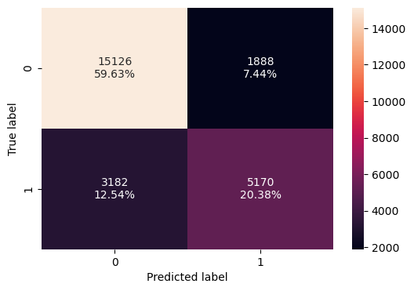

```python
confusion_matrix_statsmodels(lg, X_train_log, y_train)
```

```python
print("Training performance:")
model_performance_classification_statsmodels(lg, X_train_log, y_train)
```

```
Training performance:
```

|  | Accuracy | Recall | Precision | F1 |
| --- | --- | --- | --- | --- |
| 0 | 0.800126 | 0.619013 | 0.732502 | 0.670993 |

**Observations**

- The f1_score of the model is ~0.67 and we will try to maximize it further
- The variables used to build the model might contain multicollinearity, which will affect the p-values
- We will have to remove multicollinearity from the data to get reliable coefficients and p-values

## Checking Multicollinearity

- In order to make statistical inferences from a logistic regression model, it is important to ensure that there is no multicollinearity present in the data.

### Detecting and Dealing with Multicollinearity

There are different ways of detecting (or testing for) multicollinearity. One such way is using the Variation Inflation Factor (VIF).

- **Variance Inflation factor**: Variance inflation factors measure the inflation in the variances of the regression coefficients estimates due to collinearities that exist among the predictors. It is a measure of how much the variance of the estimated regression coefficient $\beta_k$ is "inflated" by the existence of correlation among the predictor variables in the model.
- **General Rule of thumb**:
  - If VIF is 1 then there is no correlation among the $k$th predictor and the remaining predictor variables, and hence the variance of $\beta_k$ is not inflated at all
  - If VIF exceeds 5, we say there is moderate multicollinearity
  - If VIF is equal or exceeding 10, it shows signs of high multi-collinearity
- The purpose of the analysis should dictate which threshold to use

```python
all_columns = list(X_train_log.columns)
```

```python
all_columns.remove('const')
```

```python
X_train_log=X_train_log[all_columns]
```

```python
vif_series = pd.Series(
    [variance_inflation_factor(X_train_log.values, i) for i in range(X_train_log.shape[1])],
    index=X_train_log.columns,
    dtype=float,
)
print("Series before feature selection: \n\n{}\n".format(vif_series))
```

```
Series before feature selection:

no_of_adults                                            18.792506
no_of_weekend_nights                                     3.663401
no_of_week_nights                                        5.016424
required_car_parking_space                               1.075176
arrival_year                                           310.839565
arrival_month                                            7.194917
repeated_guest                                          20.308456
avg_price_per_room                                      18.980747
no_of_special_requests                                   2.042103
type_of_meal_plan_Meal Plan 2                            1.365471
type_of_meal_plan_Meal Plan 3                            1.032090
type_of_meal_plan_Not Selected                           1.443305
room_type_reserved_Room_Type 2                           1.183255
room_type_reserved_Room_Type 3                           1.003600
room_type_reserved_Room_Type 4                           1.634155
room_type_reserved_Room_Type 5                           1.043341
room_type_reserved_Room_Type 6                           2.987664
room_type_reserved_Room_Type 7                           1.182826
market_segment_type_Complementary                        4.280998
market_segment_type_Corporate                           16.634050
market_segment_type_Offline                             84.008396
market_segment_type_Online                             183.141616
DayofWeek_Monday                                         2.697910
DayofWeek_Saturday                                       2.168034
DayofWeek_Sunday                                         2.534825
DayofWeek_Thursday                                       1.972228
DayofWeek_Tuesday                                        3.378282
DayofWeek_Wednesday                                      2.643856
lead_time_bin_30_to_90_days                              2.098734
lead_time_bin_90_days_to_half_year                       1.850255
lead_time_bin_half_year_to_year                          1.687293
lead_time_bin_more_than_year                             1.086302
no_of_children_bin_1                                     1.114814
no_of_children_bin_2                                     3.007951
no_of_children_bin_3                                     1.040165
no_of_children_bin_4 or more                             1.001762
no_of_previous_bookings_not_canceled_bin_1               5.901627
no_of_previous_bookings_not_canceled_bin_2               3.344145
no_of_previous_bookings_not_canceled_bin_3               2.532439
no_of_previous_bookings_not_canceled_bin_4               2.304523
no_of_previous_bookings_not_canceled_bin_5               1.871139
no_of_previous_bookings_not_canceled_bin_6               1.654730
no_of_previous_bookings_not_canceled_bin_7               1.406118
no_of_previous_bookings_not_canceled_bin_8               1.349175
no_of_previous_bookings_not_canceled_bin_9               1.283078
no_of_previous_bookings_not_canceled_bin_10              1.338040
no_of_previous_bookings_not_canceled_bin_11 or more      4.148318
no_of_previous_cancellations_bin_1                       2.531456
no_of_previous_cancellations_bin_2                       1.162854
no_of_previous_cancellations_bin_3                       1.376075
no_of_previous_cancellations_bin_4                       1.104554
no_of_previous_cancellations_bin_5                       1.102952
no_of_previous_cancellations_bin_6 or more               1.123923
dtype: float64
```

**Removing `arrival_year`**

```python
X_train_log1 = X_train_log.drop("arrival_year", axis=1)

vif_series2 = pd.Series(
    [variance_inflation_factor(X_train_log1.values, i) for i in range(X_train_log1.shape[1])],
    index=X_train_log1.columns,
)
print("Series before feature selection: \n\n{}\n".format(vif_series2))
```

```
Series before feature selection:

no_of_adults                                           18.718933
no_of_weekend_nights                                    3.663294
no_of_week_nights                                       4.900479
required_car_parking_space                              1.075132
arrival_month                                           7.106820
repeated_guest                                         20.308406
avg_price_per_room                                     18.289698
no_of_special_requests                                  2.038173
type_of_meal_plan_Meal Plan 2                           1.363364
type_of_meal_plan_Meal Plan 3                           1.032063
type_of_meal_plan_Not Selected                          1.439215
room_type_reserved_Room_Type 2                          1.182412
room_type_reserved_Room_Type 3                          1.003588
room_type_reserved_Room_Type 4                          1.634146
room_type_reserved_Room_Type 5                          1.042576
room_type_reserved_Room_Type 6                          2.978452
room_type_reserved_Room_Type 7                          1.181032
market_segment_type_Complementary                       1.378593
market_segment_type_Corporate                           2.815484
market_segment_type_Offline                            11.772325
market_segment_type_Online                             28.262170
DayofWeek_Monday                                        2.657571
DayofWeek_Saturday                                      2.138353
DayofWeek_Sunday                                        2.496146
DayofWeek_Thursday                                      1.948776
DayofWeek_Tuesday                                       3.327316
DayofWeek_Wednesday                                     2.592234
lead_time_bin_30_to_90_days                             2.098308
lead_time_bin_90_days_to_half_year                      1.849591
lead_time_bin_half_year_to_year                         1.686804
lead_time_bin_more_than_year                            1.086302
no_of_children_bin_1                                    1.114564
no_of_children_bin_2                                    3.007927
no_of_children_bin_3                                    1.040164
no_of_children_bin_4 or more                            1.001755
no_of_previous_bookings_not_canceled_bin_1              5.893305
no_of_previous_bookings_not_canceled_bin_2              3.343314
no_of_previous_bookings_not_canceled_bin_3              2.532196
no_of_previous_bookings_not_canceled_bin_4              2.303392
no_of_previous_bookings_not_canceled_bin_5              1.871081
no_of_previous_bookings_not_canceled_bin_6              1.654632
no_of_previous_bookings_not_canceled_bin_7              1.406094
no_of_previous_bookings_not_canceled_bin_8              1.349154
no_of_previous_bookings_not_canceled_bin_9              1.282961
no_of_previous_bookings_not_canceled_bin_10             1.337939
no_of_previous_bookings_not_canceled_bin_11 or more     4.148068
no_of_previous_cancellations_bin_1                      2.531302
no_of_previous_cancellations_bin_2                      1.161291
no_of_previous_cancellations_bin_3                      1.375996
no_of_previous_cancellations_bin_4                      1.104540
no_of_previous_cancellations_bin_5                      1.102952
no_of_previous_cancellations_bin_6 or more              1.123920
dtype: float64
```

**Removing `market_segment_type_Online`**

```python
X_train_log2 = X_train_log1.drop("market_segment_type_Online", axis=1)
vif_series3 = pd.Series(
    [variance_inflation_factor(X_train_log2.values, i) for i in range(X_train_log2.shape[1])],
    index=X_train_log2.columns,
)
print("Series before feature selection: \n\n{}\n".format(vif_series3))
```

```
Series before feature selection:

no_of_adults                                           15.223460
no_of_weekend_nights                                    3.644675
no_of_week_nights                                       4.546968
required_car_parking_space                              1.075104
arrival_month                                           6.667047
repeated_guest                                         20.285470
avg_price_per_room                                     13.897605
no_of_special_requests                                  2.031694
type_of_meal_plan_Meal Plan 2                           1.345629
type_of_meal_plan_Meal Plan 3                           1.031911
type_of_meal_plan_Not Selected                          1.377072
room_type_reserved_Room_Type 2                          1.173482
room_type_reserved_Room_Type 3                          1.003498
room_type_reserved_Room_Type 4                          1.579099
room_type_reserved_Room_Type 5                          1.037716
room_type_reserved_Room_Type 6                          2.892530
room_type_reserved_Room_Type 7                          1.162309
market_segment_type_Complementary                       1.255681
market_segment_type_Corporate                           1.500535
market_segment_type_Offline                             2.040185
DayofWeek_Monday                                        2.393840
DayofWeek_Saturday                                      1.988850
DayofWeek_Sunday                                        2.260146
DayofWeek_Thursday                                      1.807492
DayofWeek_Tuesday                                       3.012001
DayofWeek_Wednesday                                     2.351904
lead_time_bin_30_to_90_days                             2.053494
lead_time_bin_90_days_to_half_year                      1.820539
lead_time_bin_half_year_to_year                         1.672430
lead_time_bin_more_than_year                            1.085700
no_of_children_bin_1                                    1.114130
no_of_children_bin_2                                    2.996094
no_of_children_bin_3                                    1.040079
no_of_children_bin_4 or more                            1.001645
no_of_previous_bookings_not_canceled_bin_1              5.891141
no_of_previous_bookings_not_canceled_bin_2              3.342933
no_of_previous_bookings_not_canceled_bin_3              2.532106
no_of_previous_bookings_not_canceled_bin_4              2.303356
no_of_previous_bookings_not_canceled_bin_5              1.870946
no_of_previous_bookings_not_canceled_bin_6              1.654620
no_of_previous_bookings_not_canceled_bin_7              1.406046
no_of_previous_bookings_not_canceled_bin_8              1.349121
no_of_previous_bookings_not_canceled_bin_9              1.282944
no_of_previous_bookings_not_canceled_bin_10             1.337920
no_of_previous_bookings_not_canceled_bin_11 or more     4.148031
no_of_previous_cancellations_bin_1                      2.530933
no_of_previous_cancellations_bin_2                      1.161235
no_of_previous_cancellations_bin_3                      1.375888
no_of_previous_cancellations_bin_4                      1.104471
no_of_previous_cancellations_bin_5                      1.102882
no_of_previous_cancellations_bin_6 or more              1.123574
dtype: float64
```

```python
X_train_log3 = X_train_log2.drop("repeated_guest", axis=1)
vif_series4 = pd.Series(
    [variance_inflation_factor(X_train_log3.values, i) for i in range(X_train_log3.shape[1])],
    index=X_train_log3.columns,
)
print("Series before feature selection: \n\n{}\n".format(vif_series4))
```

```
Series before feature selection:

no_of_adults                                           15.221806
no_of_weekend_nights                                    3.644675
no_of_week_nights                                       4.546244
required_car_parking_space                              1.074504
arrival_month                                           6.662092
avg_price_per_room                                     13.897341
no_of_special_requests                                  2.031690
type_of_meal_plan_Meal Plan 2                           1.345433
type_of_meal_plan_Meal Plan 3                           1.031911
type_of_meal_plan_Not Selected                          1.377071
room_type_reserved_Room_Type 2                          1.173456
room_type_reserved_Room_Type 3                          1.003490
room_type_reserved_Room_Type 4                          1.579057
room_type_reserved_Room_Type 5                          1.037716
room_type_reserved_Room_Type 6                          2.892530
room_type_reserved_Room_Type 7                          1.162306
market_segment_type_Complementary                       1.253960
market_segment_type_Corporate                           1.500353
market_segment_type_Offline                             2.037386
DayofWeek_Monday                                        2.393055
DayofWeek_Saturday                                      1.988245
DayofWeek_Sunday                                        2.259426
DayofWeek_Thursday                                      1.806276
DayofWeek_Tuesday                                       3.011369
DayofWeek_Wednesday                                     2.351435
lead_time_bin_30_to_90_days                             2.050154
lead_time_bin_90_days_to_half_year                      1.817293
lead_time_bin_half_year_to_year                         1.670023
lead_time_bin_more_than_year                            1.085598
no_of_children_bin_1                                    1.114113
no_of_children_bin_2                                    2.996060
no_of_children_bin_3                                    1.040076
no_of_children_bin_4 or more                            1.001644
no_of_previous_bookings_not_canceled_bin_1              1.104948
no_of_previous_bookings_not_canceled_bin_2              1.072784
no_of_previous_bookings_not_canceled_bin_3              1.053905
no_of_previous_bookings_not_canceled_bin_4              1.070370
no_of_previous_bookings_not_canceled_bin_5              1.075013
no_of_previous_bookings_not_canceled_bin_6              1.055283
no_of_previous_bookings_not_canceled_bin_7              1.033537
no_of_previous_bookings_not_canceled_bin_8              1.037912
no_of_previous_bookings_not_canceled_bin_9              1.011536
no_of_previous_bookings_not_canceled_bin_10             1.038571
no_of_previous_bookings_not_canceled_bin_11 or more     1.714002
no_of_previous_cancellations_bin_1                      1.102385
no_of_previous_cancellations_bin_2                      1.141597
no_of_previous_cancellations_bin_3                      1.363162
no_of_previous_cancellations_bin_4                      1.102736
no_of_previous_cancellations_bin_5                      1.100507
no_of_previous_cancellations_bin_6 or more              1.088274
dtype: float64
```

```python
X_train_log4 = X_train_log3.drop("no_of_adults", axis=1)
vif_series5 = pd.Series(
    [variance_inflation_factor(X_train_log4.values, i) for i in range(X_train_log4.shape[1])],
    index=X_train_log4.columns,
)
print("Series before feature selection: \n\n{}\n".format(vif_series5))
```

```
Series before feature selection:

no_of_weekend_nights                                    3.644672
no_of_week_nights                                       4.378202
required_car_parking_space                              1.073574
arrival_month                                           6.588464
avg_price_per_room                                     10.343952
no_of_special_requests                                  1.994139
type_of_meal_plan_Meal Plan 2                           1.340677
type_of_meal_plan_Meal Plan 3                           1.031864
type_of_meal_plan_Not Selected                          1.337023
room_type_reserved_Room_Type 2                          1.172381
room_type_reserved_Room_Type 3                          1.003421
room_type_reserved_Room_Type 4                          1.541639
room_type_reserved_Room_Type 5                          1.036744
room_type_reserved_Room_Type 6                          2.883550
room_type_reserved_Room_Type 7                          1.161492
market_segment_type_Complementary                       1.222873
market_segment_type_Corporate                           1.500152
market_segment_type_Offline                             1.995955
DayofWeek_Monday                                        2.295240
DayofWeek_Saturday                                      1.929500
DayofWeek_Sunday                                        2.156279
DayofWeek_Thursday                                      1.777750
DayofWeek_Tuesday                                       2.896705
DayofWeek_Wednesday                                     2.285048
lead_time_bin_30_to_90_days                             1.978735
lead_time_bin_90_days_to_half_year                      1.757969
lead_time_bin_half_year_to_year                         1.629257
lead_time_bin_more_than_year                            1.083255
no_of_children_bin_1                                    1.113448
no_of_children_bin_2                                    2.904000
no_of_children_bin_3                                    1.038917
no_of_children_bin_4 or more                            1.001594
no_of_previous_bookings_not_canceled_bin_1              1.104819
no_of_previous_bookings_not_canceled_bin_2              1.072758
no_of_previous_bookings_not_canceled_bin_3              1.053897
no_of_previous_bookings_not_canceled_bin_4              1.070304
no_of_previous_bookings_not_canceled_bin_5              1.075004
no_of_previous_bookings_not_canceled_bin_6              1.055227
no_of_previous_bookings_not_canceled_bin_7              1.033462
no_of_previous_bookings_not_canceled_bin_8              1.037868
no_of_previous_bookings_not_canceled_bin_9              1.011518
no_of_previous_bookings_not_canceled_bin_10             1.038503
no_of_previous_bookings_not_canceled_bin_11 or more     1.713665
no_of_previous_cancellations_bin_1                      1.102090
no_of_previous_cancellations_bin_2                      1.141586
no_of_previous_cancellations_bin_3                      1.363069
no_of_previous_cancellations_bin_4                      1.102722
no_of_previous_cancellations_bin_5                      1.100491
no_of_previous_cancellations_bin_6 or more              1.087559
dtype: float64
```

```python
X_train_log5 = X_train_log4.drop("avg_price_per_room", axis=1)
vif_series6 = pd.Series(
    [variance_inflation_factor(X_train_log5.values, i) for i in range(X_train_log5.shape[1])],
    index=X_train_log5.columns,
)
print("Series before feature selection: \n\n{}\n".format(vif_series6))
```

```
Series before feature selection:

no_of_weekend_nights                                   3.590394
no_of_week_nights                                      4.089747
required_car_parking_space                             1.065669
arrival_month                                          5.677343
no_of_special_requests                                 1.945918
type_of_meal_plan_Meal Plan 2                          1.298039
type_of_meal_plan_Meal Plan 3                          1.031857
type_of_meal_plan_Not Selected                         1.330336
room_type_reserved_Room_Type 2                         1.171390
room_type_reserved_Room_Type 3                         1.003421
room_type_reserved_Room_Type 4                         1.380867
room_type_reserved_Room_Type 5                         1.025668
room_type_reserved_Room_Type 6                         2.768530
room_type_reserved_Room_Type 7                         1.137876
market_segment_type_Complementary                      1.139297
market_segment_type_Corporate                          1.497750
market_segment_type_Offline                            1.995262
DayofWeek_Monday                                       2.024759
DayofWeek_Saturday                                     1.737041
DayofWeek_Sunday                                       1.889841
DayofWeek_Thursday                                     1.625988
DayofWeek_Tuesday                                      2.556144
DayofWeek_Wednesday                                    1.996693
lead_time_bin_30_to_90_days                            1.967944
lead_time_bin_90_days_to_half_year                     1.748780
lead_time_bin_half_year_to_year                        1.628342
lead_time_bin_more_than_year                           1.082826
no_of_children_bin_1                                   1.095998
no_of_children_bin_2                                   2.891508
no_of_children_bin_3                                   1.038607
no_of_children_bin_4 or more                           1.001594
no_of_previous_bookings_not_canceled_bin_1             1.104297
no_of_previous_bookings_not_canceled_bin_2             1.072266
no_of_previous_bookings_not_canceled_bin_3             1.053441
no_of_previous_bookings_not_canceled_bin_4             1.070237
no_of_previous_bookings_not_canceled_bin_5             1.074908
no_of_previous_bookings_not_canceled_bin_6             1.055035
no_of_previous_bookings_not_canceled_bin_7             1.033388
no_of_previous_bookings_not_canceled_bin_8             1.037509
no_of_previous_bookings_not_canceled_bin_9             1.011508
no_of_previous_bookings_not_canceled_bin_10            1.038365
no_of_previous_bookings_not_canceled_bin_11 or more    1.712848
no_of_previous_cancellations_bin_1                     1.101969
no_of_previous_cancellations_bin_2                     1.141539
no_of_previous_cancellations_bin_3                     1.363069
no_of_previous_cancellations_bin_4                     1.102460
no_of_previous_cancellations_bin_5                     1.100385
no_of_previous_cancellations_bin_6 or more             1.087369
dtype: float64
```

```python
X_train_log6 = X_train_log5.drop("arrival_month", axis=1)
vif_series7 = pd.Series(
    [variance_inflation_factor(X_train_log6.values, i) for i in range(X_train_log6.shape[1])],
    index=X_train_log6.columns,
)
print("Series before feature selection: \n\n{}\n".format(vif_series7))
```

```
Series before feature selection:

no_of_weekend_nights                                   3.567184
no_of_week_nights                                      3.805752
required_car_parking_space                             1.065537
no_of_special_requests                                 1.827319
type_of_meal_plan_Meal Plan 2                          1.297971
type_of_meal_plan_Meal Plan 3                          1.031843
type_of_meal_plan_Not Selected                         1.297753
room_type_reserved_Room_Type 2                         1.171290
room_type_reserved_Room_Type 3                         1.003256
room_type_reserved_Room_Type 4                         1.372541
room_type_reserved_Room_Type 5                         1.025389
room_type_reserved_Room_Type 6                         2.766496
room_type_reserved_Room_Type 7                         1.137720
market_segment_type_Complementary                      1.133862
market_segment_type_Corporate                          1.464652
market_segment_type_Offline                            1.927604
DayofWeek_Monday                                       1.803352
DayofWeek_Saturday                                     1.596796
DayofWeek_Sunday                                       1.695720
DayofWeek_Thursday                                     1.521618
DayofWeek_Tuesday                                      2.335722
DayofWeek_Wednesday                                    1.818620
lead_time_bin_30_to_90_days                            1.940940
lead_time_bin_90_days_to_half_year                     1.726627
lead_time_bin_half_year_to_year                        1.563384
lead_time_bin_more_than_year                           1.077832
no_of_children_bin_1                                   1.095615
no_of_children_bin_2                                   2.891490
no_of_children_bin_3                                   1.038591
no_of_children_bin_4 or more                           1.001580
no_of_previous_bookings_not_canceled_bin_1             1.102801
no_of_previous_bookings_not_canceled_bin_2             1.072130
no_of_previous_bookings_not_canceled_bin_3             1.053358
no_of_previous_bookings_not_canceled_bin_4             1.070230
no_of_previous_bookings_not_canceled_bin_5             1.074894
no_of_previous_bookings_not_canceled_bin_6             1.055018
no_of_previous_bookings_not_canceled_bin_7             1.033386
no_of_previous_bookings_not_canceled_bin_8             1.037507
no_of_previous_bookings_not_canceled_bin_9             1.011500
no_of_previous_bookings_not_canceled_bin_10            1.038359
no_of_previous_bookings_not_canceled_bin_11 or more    1.711808
no_of_previous_cancellations_bin_1                     1.098312
no_of_previous_cancellations_bin_2                     1.141466
no_of_previous_cancellations_bin_3                     1.362902
no_of_previous_cancellations_bin_4                     1.102396
no_of_previous_cancellations_bin_5                     1.099939
no_of_previous_cancellations_bin_6 or more             1.085959
dtype: float64
```

```python
# fitting logistic regression model
logit = sm.Logit(y_train, X_train_log6)
lg = logit.fit(disp=False)

print(lg.summary())
```

```
                           Logit Regression Results
==============================================================================
Dep. Variable:          target_binary   No. Observations:                25366
Model:                          Logit   Df Residuals:                    25319
Method:                           MLE   Df Model:                           46
Date:                Thu, 13 Jul 2023   Pseudo R-squ.:                  0.2941
Time:                        16:31:04   Log-Likelihood:                -11346.
converged:                      False   LL-Null:                       -16073.
Covariance Type:            nonrobust   LLR p-value:                     0.000
=======================================================================================================================
                                                          coef    std err          z      P>|z|      [0.025      0.975]
-----------------------------------------------------------------------------------------------------------------------
no_of_weekend_nights                                    0.1774      0.026      6.861      0.000       0.127       0.228
no_of_week_nights                                      -0.0895      0.012     -7.399      0.000      -0.113      -0.066
required_car_parking_space                             -1.4541      0.133    -10.912      0.000      -1.715      -1.193
no_of_special_requests                                 -1.5016      0.029    -52.105      0.000      -1.558      -1.445
type_of_meal_plan_Meal Plan 2                           0.5545      0.060      9.208      0.000       0.437       0.673
type_of_meal_plan_Meal Plan 3                          23.0359   3.72e+04      0.001      1.000    -7.3e+04     7.3e+04
type_of_meal_plan_Not Selected                         -0.0779      0.049     -1.598      0.110      -0.174       0.018
room_type_reserved_Room_Type 2                         -0.9842      0.134     -7.329      0.000      -1.247      -0.721
room_type_reserved_Room_Type 3                          0.0371      1.219      0.030      0.976      -2.352       2.426
room_type_reserved_Room_Type 4                          0.1797      0.047      3.821      0.000       0.087       0.272
room_type_reserved_Room_Type 5                          0.0995      0.208      0.478      0.633      -0.308       0.507
room_type_reserved_Room_Type 6                          0.1658      0.174      0.953      0.341      -0.175       0.507
room_type_reserved_Room_Type 7                          0.4018      0.302      1.332      0.183      -0.190       0.993
market_segment_type_Complementary                     -43.8214   4.61e+04     -0.001      0.999   -9.03e+04    9.02e+04
market_segment_type_Corporate                          -1.4316      0.095    -15.097      0.000      -1.617      -1.246
market_segment_type_Offline                            -2.1166      0.048    -44.304      0.000      -2.210      -2.023
DayofWeek_Monday                                       -0.7037      0.058    -12.187      0.000      -0.817      -0.591
DayofWeek_Saturday                                     -0.4649      0.054     -8.603      0.000      -0.571      -0.359
DayofWeek_Sunday                                       -0.4619      0.052     -8.945      0.000      -0.563      -0.361
DayofWeek_Thursday                                     -0.2422      0.057     -4.240      0.000      -0.354      -0.130
DayofWeek_Tuesday                                      -0.6412      0.068     -9.433      0.000      -0.774      -0.508
DayofWeek_Wednesday                                    -0.5505      0.058     -9.433      0.000      -0.665      -0.436
lead_time_bin_30_to_90_days                             0.6851      0.044     15.749      0.000       0.600       0.770
lead_time_bin_90_days_to_half_year                      1.8348      0.048     38.582      0.000       1.742       1.928
lead_time_bin_half_year_to_year                         3.4820      0.062     56.582      0.000       3.361       3.603
lead_time_bin_more_than_year                            6.0314      0.397     15.210      0.000       5.254       6.809
no_of_children_bin_1                                    0.4481      0.084      5.346      0.000       0.284       0.612
no_of_children_bin_2                                    0.7308      0.168      4.358      0.000       0.402       1.059
```

[output cut: 20 more lines]

```python
logit2 = sm.Logit(y_train, X_train_log6)
lg2 = logit2.fit(disp=False)

print("Training performance:")
model_performance_classification_statsmodels(lg2, X_train_log6, y_train)
```

```
Training performance:
```

|  | Accuracy | Recall | Precision | F1 |
| --- | --- | --- | --- | --- |
| 0 | 0.786959 | 0.581178 | 0.718047 | 0.642403 |

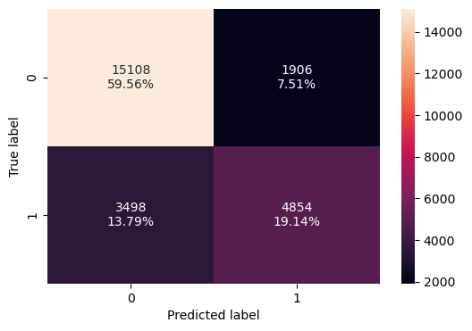

```python
# creating confusion matrix
confusion_matrix_statsmodels(lg2, X_train_log6, y_train)
```

```python
log_reg_model_train_perf = model_performance_classification_statsmodels(
    lg2, X_train_log6, y_train
)

print("Training performance:")
log_reg_model_train_perf
```

```
Training performance:
```

|  | Accuracy | Recall | Precision | F1 |
| --- | --- | --- | --- | --- |
| 0 | 0.786959 | 0.581178 | 0.718047 | 0.642403 |

```python
X_test3 = X_test[list(X_train_log6.columns)]
```

### Checking performance of the new model

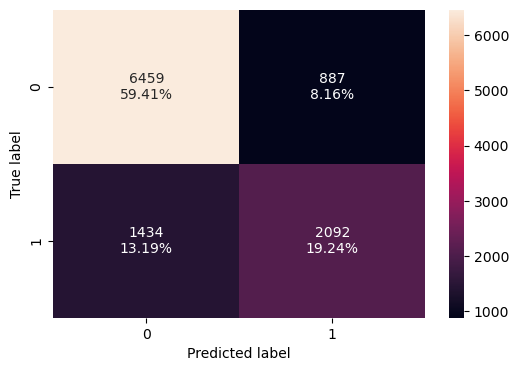

```python
confusion_matrix_statsmodels(lg2, X_test3, y_test)
```

```python
log_reg_model_test_perf = model_performance_classification_statsmodels(
    lg2, X_test3, y_test
)

print("Test performance:")
log_reg_model_test_perf
```

```
Test performance:
```

|  | Accuracy | Recall | Precision | F1 |
| --- | --- | --- | --- | --- |
| 0 | 0.786516 | 0.593307 | 0.702249 | 0.643198 |

- The model is giving a good f1_score of ~0.642 and ~0.643 on the train and test sets respectively
- As the train and test performances are comparable, the model is not overfitting
- Moving forward we will try to improve the performance of the model

## Model Performance Improvement

- Let's see if the f1_score can be improved further by changing the model threshold
- First, we will check the ROC curve, compute the area under the ROC curve (ROC-AUC), and then use it to find the optimal threshold
- Next, we will check the Precision-Recall curve to find the right balance between precision and recall as our metric of choice is f1_score

## ROC Curve and ROC-AUC

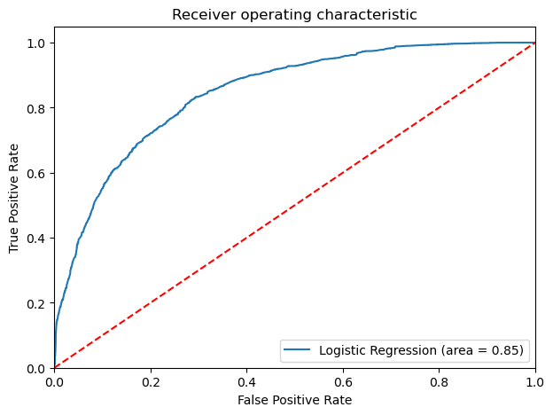

```python
logit_roc_auc_train = roc_auc_score(y_train, lg2.predict(X_train_log6))
fpr, tpr, thresholds = roc_curve(y_train, lg2.predict(X_train_log6))
plt.figure(figsize=(7, 5))
plt.plot(fpr, tpr, label="Logistic Regression (area = %0.2f)" % logit_roc_auc_train)
plt.plot([0, 1], [0, 1], "r--")
plt.xlim([0.0, 1.0])
plt.ylim([0.0, 1.05])
plt.xlabel("False Positive Rate")
plt.ylabel("True Positive Rate")
plt.title("Receiver operating characteristic")
plt.legend(loc="lower right")
plt.show()
```

- Logistic Regression model is giving a good performance on training set.

### Optimal threshold using AUC-ROC curve

```python
# Optimal threshold as per AUC-ROC curve
# The optimal cut off would be where tpr is high and fpr is low
fpr, tpr, thresholds = roc_curve(y_train, lg2.predict(X_train_log6))

optimal_idx = np.argmax(tpr - fpr)
optimal_threshold_auc_roc = thresholds[optimal_idx]
print(optimal_threshold_auc_roc)
```

```
0.2843809472213473
```

**Checking model performance on training set**

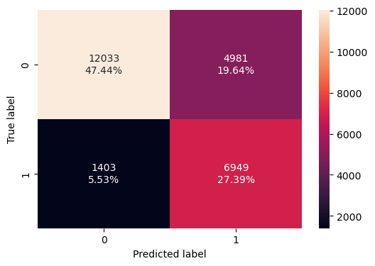

```python
# creating confusion matrix
confusion_matrix_statsmodels(
    lg2, X_train_log6, y_train, threshold=optimal_threshold_auc_roc
)
```

```python
# checking model performance for this model
log_reg_model_train_perf_threshold_auc_roc = model_performance_classification_statsmodels(
    lg2, X_train_log6, y_train, threshold=optimal_threshold_auc_roc
)
print("Training performance:")
log_reg_model_train_perf_threshold_auc_roc
```

```
Training performance:
```

|  | Accuracy | Recall | Precision | F1 |
| --- | --- | --- | --- | --- |
| 0 | 0.748325 | 0.832016 | 0.582481 | 0.685238 |

Recall has increased

**Checking model performance on test set**

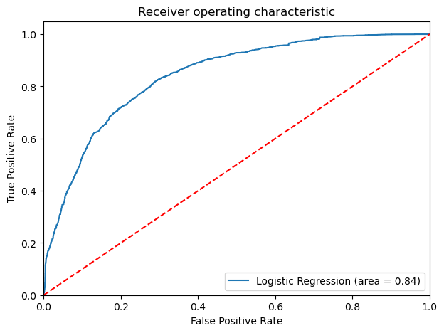

```python
logit_roc_auc_train = roc_auc_score(y_test, lg2.predict(X_test3))
fpr, tpr, thresholds = roc_curve(y_test, lg2.predict(X_test3))
plt.figure(figsize=(7, 5))
plt.plot(fpr, tpr, label="Logistic Regression (area = %0.2f)" % logit_roc_auc_train)
plt.plot([0, 1], [0, 1], "r--")
plt.xlim([0.0, 1.0])
plt.ylim([0.0, 1.05])
plt.xlabel("False Positive Rate")
plt.ylabel("True Positive Rate")
plt.title("Receiver operating characteristic")
plt.legend(loc="lower right")
plt.show()
```

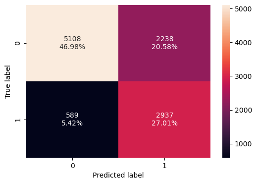

```python
confusion_matrix_statsmodels(lg2, X_test3, y_test, threshold=optimal_threshold_auc_roc)
```

```python
# checking model performance for this model
log_reg_model_test_perf_threshold_auc_roc = model_performance_classification_statsmodels(
    lg2, X_test3, y_test, threshold=optimal_threshold_auc_roc
)
print("Test performance:")
log_reg_model_test_perf_threshold_auc_roc
```

```
Test performance:
```

|  | Accuracy | Recall | Precision | F1 |
| --- | --- | --- | --- | --- |
| 0 | 0.739974 | 0.832955 | 0.567536 | 0.675095 |